# 4569_Batch115_Nikhil_modelling

**Problem Statement:** Predicting the retail customer retention potential level as high/medium/low & Customer Segmentation & Pattern extraction

- Employee retention is defined as an organization's ability to prevent employee turnover, or the number of people who leave their job in a certain period, either voluntarily or involuntarily. Increasing employee retention has a direct impact on business performance and success.

The business problem is to predict retail customer retention potential and classify customers as high/medium/low to make suitable marketing programsfor customer retention.

There are 18 attributes which represents the following -

*CustomerID:* A unique identifier assigned to each customer in the database.

*City:* The city where the customer is located.

*OnlineCommunication*: A binary variable that indicates whether the customer has communicated with the company online.

*AutomaticRefill:* A binary variable that indicates whether the customer has opted for automatic refill of their orders.

*DoorstepDelivery:* A binary variable that indicates whether the customer has opted for doorstep delivery of their orders.

*PreferredDeliveryDay:* The day of the week on which the customer prefers to receive their orders.

*Welcome_email_opened:* A binary variable that indicates whether the customer has opened the welcome email sent by the company.

*No_of_customized_email:* The number of customized emails sent to the customer.

*No_of_customized_email_opened:* The number of customized emails opened by the customer.

*No_of_customized_email_clicked:* The number of links clicked by the customer in the customized emails.

*RetentionPotential*: A classification that predicts the likelihood of the customer to continue using the company's services.

*TotalOrderQuantity:* The total quantity of orders placed by the customer.

*OrderFrequency:* The frequency of orders placed by the customer.

*Average_Ordergap:* The average time between orders placed by the customer.

*no_of_BusinessDays:* The number of business days between orders placed by the customer.

*DateOfRegistration:* The date on which the customer registered with the company or created an account.

*DateOfOrder:* The date on which the customer placed an order or made a purchase.

*Timestamp:* A column that contains the exact date and time at which an event occurred.

```python
#importing libraries
import numpy as np
import pandas as pd
import matplotlib.pyplot as plt
import seaborn as sns
from collections import Counter
from itertools import product
from google.colab import drive
```

```python
drive.mount('/content/drive')
```

```python
train_df1=pd.read_excel('/content/drive/MyDrive/Hackathon/TrainData/Train.xlsx')
customer_df=pd.read_excel('/content/drive/MyDrive/Hackathon/TrainData/Customerdata_Train.xlsx')
```

```python
email_df=pd.read_excel('/content/drive/MyDrive/Hackathon/TrainData/Emaildata_Train.xlsx')
transaction_df=pd.read_excel('/content/drive/MyDrive/Hackathon/TrainData/transactionsdata_Train.xlsx')
```

```python
# Set the max_columns option to display all columns
pd.set_option('display.max_columns', None)
```

# Exploratory Data Analysis(EDA):

```python
train_df1
```

|  | CustomerID | RetentionPotential |
| --- | --- | --- |
| 0 | C37869 | Low |
| 1 | C33841 | Low |
| 2 | C29464 | Low |
| 3 | C28158 | Low |
| 4 | C22785 | High |
| ... | ... | ... |
| 23815 | C14975 | Low |
| 23816 | C30392 | Low |
| 23817 | C41735 | Low |
| 23818 | C26055 | Low |
| 23819 | C25058 | High |

23820 rows × 2 columns

```python
customer_df
```

|  | CustomerID | City | DateOfRegistration | OnlineCommunication | AutomaticRefill | DoorstepDelivery | PreferredDeliveryDay |
| --- | --- | --- | --- | --- | --- | --- | --- |
| 0 | C16368 | CITY2 | 2012-09-28 | 0 | 0 | 0 | Monday |
| 1 | C20345 | CITY2 | 2010-12-19 | 1 | 1 | 1 | Friday |
| 2 | C17683 | CITY2 | 2010-10-03 | 0 | 0 | 0 | Wednesday |
| 3 | C18647 | CITY4 | 2010-11-27 | 0 | 0 | 0 | Monday |
| 4 | C36692 | CITY2 | 2009-12-04 | 1 | 1 | 0 | Friday |
| ... | ... | ... | ... | ... | ... | ... | ... |
| 23815 | C23511 | CITY2 | 2018-01-17 | 1 | 1 | 0 | Friday |
| 23816 | C12197 | CITY3 | 2018-01-17 | 1 | 0 | 1 | Friday |
| 23817 | C40967 | CITY3 | 2018-01-17 | 1 | 0 | 0 | Saturday |
| 23818 | C36140 | CITY3 | 2018-01-17 | 1 | 1 | 0 | Saturday |
| 23819 | C42003 | CITY4 | 2018-01-17 | 1 | 0 | 0 | Friday |

23820 rows × 7 columns

```python
email_df
```

|  | CustomerID | DateOfemail | EmailType | timestamp | MailOpened | MailClicked |
| --- | --- | --- | --- | --- | --- | --- |
| 0 | C16368 | 2012-09-28 | WelcomeEmail | 15:56:50 | yes | NotApplicable |
| 1 | C20345 | 2010-12-19 | WelcomeEmail | 15:10:30 | yes | NotApplicable |
| 2 | C17683 | 2010-10-03 | WelcomeEmail | 17:12:24 | yes | NotApplicable |
| 3 | C18647 | 2010-11-27 | WelcomeEmail | 16:59:02 | yes | NotApplicable |
| 4 | C36692 | 2009-12-04 | WelcomeEmail | 17:27:22 | yes | NotApplicable |
| ... | ... | ... | ... | ... | ... | ... |
| 517667 | C36140 | 2018-01-18 | CustomizedEmail | 14:04:44 | yes | yes |
| 517668 | C36140 | 2018-01-21 | CustomizedEmail | 16:17:16 | no | no |
| 517669 | C36140 | 2018-01-20 | CustomizedEmail | 12:17:34 | yes | yes |
| 517670 | C36140 | 2018-01-20 | CustomizedEmail | 16:31:18 | yes | no |
| 517671 | C36140 | 2018-01-21 | CustomizedEmail | 14:23:16 | yes | yes |

517672 rows × 6 columns

```python
transaction_df
```

|  | CustomerID | DateOfOrder | timestamp | OrderQuantity |
| --- | --- | --- | --- | --- |
| 0 | C16368 | 2013-08-11 | 15:17:52 | 15 |
| 1 | C20345 | 2011-04-01 | 19:50:00 | 92 |
| 2 | C20345 | 2012-06-29 | 15:11:56 | 95 |
| 3 | C20345 | 2012-09-22 | 20:49:10 | 74 |
| 4 | C20345 | 2011-08-23 | 11:50:26 | 81 |
| ... | ... | ... | ... | ... |
| 104750 | C12197 | 2018-01-17 | 14:35:40 | 56 |
| 104751 | C40967 | 2018-01-17 | 17:15:20 | 35 |
| 104752 | C36140 | 2018-01-17 | 13:12:54 | 47 |
| 104753 | C36140 | 2018-01-21 | 21:12:52 | 53 |
| 104754 | C42003 | 2018-01-17 | 16:34:46 | 41 |

104755 rows × 4 columns

# checking for total null values

```python
print('----train_df1-----')
print(train_df1.isnull().sum() )
print('----customer_df-----')
print(customer_df.isnull().sum() )
print('----email_df-----')
print(email_df.isnull().sum())
print('----transaction_df-----')
print(transaction_df.isnull().sum())
```

```
----train_df1-----
CustomerID            0
RetentionPotential    0
dtype: int64
----customer_df-----
CustomerID              0
City                    0
DateOfRegistration      0
OnlineCommunication     0
AutomaticRefill         0
DoorstepDelivery        0
PreferredDeliveryDay    0
dtype: int64
----email_df-----
CustomerID     0
DateOfemail    0
EmailType      0
timestamp      0
MailOpened     0
MailClicked    0
dtype: int64
----transaction_df-----
CustomerID       0
DateOfOrder      0
timestamp        0
OrderQuantity    0
dtype: int64
```

```
   There is no  null values
```

```python
print('----train_df1-----')
print(train_df1.info() )
print('----customer_df-----')
print(customer_df.info() )
print('----email_df-----')
print(email_df.info())
```

```
----train_df1-----
<class 'pandas.core.frame.DataFrame'>
RangeIndex: 23820 entries, 0 to 23819
Data columns (total 2 columns):
 #   Column              Non-Null Count  Dtype
---  ------              --------------  -----
 0   CustomerID          23820 non-null  object
 1   RetentionPotential  23820 non-null  object
dtypes: object(2)
memory usage: 372.3+ KB
None
----customer_df-----
<class 'pandas.core.frame.DataFrame'>
RangeIndex: 23820 entries, 0 to 23819
Data columns (total 7 columns):
 #   Column                Non-Null Count  Dtype
---  ------                --------------  -----
 0   CustomerID            23820 non-null  object
 1   City                  23820 non-null  object
 2   DateOfRegistration    23820 non-null  datetime64[ns]
 3   OnlineCommunication   23820 non-null  int64
 4   AutomaticRefill       23820 non-null  int64
 5   DoorstepDelivery      23820 non-null  int64
 6   PreferredDeliveryDay  23820 non-null  object
dtypes: datetime64[ns](1), int64(3), object(3)
memory usage: 1.3+ MB
None
----email_df-----
<class 'pandas.core.frame.DataFrame'>
RangeIndex: 517672 entries, 0 to 517671
Data columns (total 6 columns):
 #   Column       Non-Null Count   Dtype
---  ------       --------------   -----
 0   CustomerID   517672 non-null  object
 1   DateOfemail  517672 non-null  object
 2   EmailType    517672 non-null  object
 3   timestamp    517672 non-null  object
 4   MailOpened   517672 non-null  object
 5   MailClicked  517672 non-null  object
dtypes: object(6)
memory usage: 23.7+ MB
None
```

```python
print('----train_df1-----')
print(train_df1.nunique() )
print('----customer_df-----')
print(customer_df.nunique() )
print('----email_df-----')
print(email_df.nunique())
print('----transaction_df-----')
print(transaction_df.nunique())
```

```
----train_df1-----
CustomerID            23820
RetentionPotential        3
dtype: int64
----customer_df-----
CustomerID              23820
City                        4
DateOfRegistration       2673
OnlineCommunication         2
AutomaticRefill             2
DoorstepDelivery            2
PreferredDeliveryDay        7
dtype: int64
----email_df-----
CustomerID     23820
DateOfemail     3382
EmailType          2
timestamp      14369
MailOpened         2
MailClicked        3
dtype: int64
----transaction_df-----
CustomerID       23820
DateOfOrder       3151
timestamp        21399
OrderQuantity      451
dtype: int64
```

```python
transaction_df.describe()
```

|  | OrderQuantity |
| --- | --- |
| count | 104755.000000 |
| mean | 81.319059 |
| std | 46.853569 |
| min | 0.000000 |
| 25% | 50.000000 |
| 50% | 71.000000 |
| 75% | 100.000000 |
| max | 1501.000000 |

the OrderQuantity column data is Right Skewed.

```python
customer_df.describe()
```

|  | OnlineCommunication | AutomaticRefill | DoorstepDelivery |
| --- | --- | --- | --- |
| count | 23820.000000 | 23820.000000 | 23820.000000 |
| mean | 0.660411 | 0.094710 | 0.037615 |
| std | 0.473580 | 0.292821 | 0.190268 |
| min | 0.000000 | 0.000000 | 0.000000 |
| 25% | 0.000000 | 0.000000 | 0.000000 |
| 50% | 1.000000 | 0.000000 | 0.000000 |
| 75% | 1.000000 | 0.000000 | 0.000000 |
| max | 1.000000 | 1.000000 | 1.000000 |

```python
email_df.describe()
```

|  | CustomerID | DateOfemail | EmailType | timestamp | MailOpened | MailClicked |
| --- | --- | --- | --- | --- | --- | --- |
| count | 517672 | 517672 | 517672 | 517672 | 517672 | 517672 |
| unique | 23820 | 3382 | 2 | 14369 | 2 | 3 |
| top | C41705 | 2013-10-11 | CustomizedEmail | 15:14:02 | no | no |
| freq | 292 | 2139 | 493852 | 64 | 369812 | 466011 |

```python
train_df1.describe()
```

|  | CustomerID | RetentionPotential |
| --- | --- | --- |
| count | 23820 | 23820 |
| unique | 23820 | 3 |
| top | C37869 | Low |
| freq | 1 | 19185 |

Here the CustomerID is repreated in the email_df and transaction_df.

**Types Of Features**

- Caregorical Features
  - Nominal Features in the dataset: City, OnlineCommunication, AutomaticRefill, DoorstepDelivery, PreferredDeliveryDay, EmailType, MailOpened, MailClicked.
  - Ordinal features : RetentionPotential(Target column)
- Numerical Feature:

  ```
  OrderQuantity
  ```

- Date and Time features:

  DateOfRegistration, DateOfemail,Timestamp (email),Timestamp (order), DateOfOrder

**Target** **column**

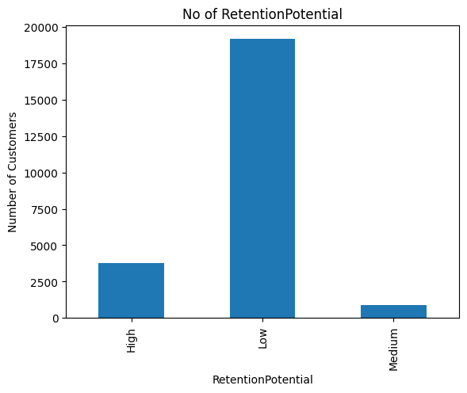

```python
#Bar plot
status_counts = train_df1.groupby('RetentionPotential')['CustomerID'].count()

# create a bar plot
status_counts.plot(kind='bar')

# add labels and title
plt.title('No of RetentionPotential')
plt.xlabel('RetentionPotential')
plt.ylabel('Number of Customers')

# show the plot
plt.show()
```

Here in RetentionPotential, many customers have low Retention Potential, and we can clearly observed that there is a class imbalance exist.

**CITY**--> Categorical Feature

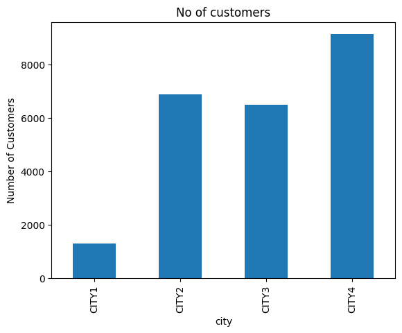

```python
#Bar plot
status_counts = customer_df.groupby('City')['CustomerID'].count()

# create a bar plot
status_counts.plot(kind='bar')

# add labels and title
plt.title('No of customers')
plt.xlabel('city')
plt.ylabel('Number of Customers')

# show the plot
plt.show()
```

**Observations**

We have the highest customers from CITY4 and lowest from CITY1

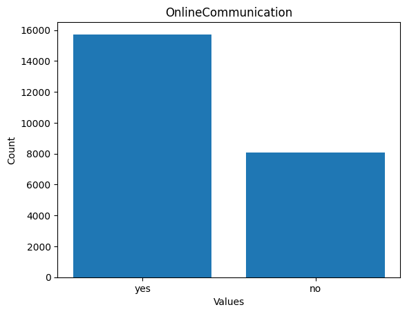

```python
# count the number of occurrences of each value
value_counts = customer_df['OnlineCommunication'].value_counts()

# create a bar plot
plt.bar(['yes', 'no'], [value_counts[1], value_counts[0]])

# set the chart title and axis labels
plt.title('OnlineCommunication')
plt.xlabel('Values')
plt.ylabel('Count')

# display the chart
plt.show()
```

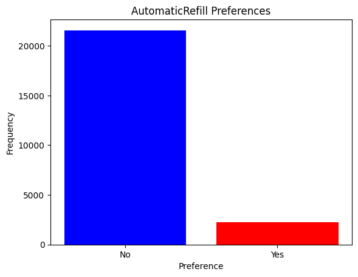

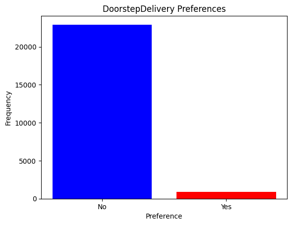

```python
  elem = [ 'AutomaticRefill', 'DoorstepDelivery']

# Iterate over each column
for col in elem:
    # Count the number of customers who preferred and did not prefer
    counts = customer_df[col].value_counts()

    # Create a bar plot
    plt.bar(['No', 'Yes'], counts.values, color=['blue', 'red'])

    # Set the title and labels
    plt.title(col + ' Preferences')
    plt.xlabel('Preference')
    plt.ylabel('Frequency')

    # Display the plot
    plt.show()
```

Observations: Here from the plot who prefers onlinecommunication is more but customers who prefers DoorstepDelivery are less.From this we can observe that the many customers who are prefered onlinecommunication are not actually ordering the items using onlinecommunication

## email_df

```python
email_df=email_df.drop(['timestamp','DateOfemail'],axis=1)
email_df
```

|  | CustomerID | EmailType | MailOpened | MailClicked |
| --- | --- | --- | --- | --- |
| 0 | C16368 | WelcomeEmail | yes | NotApplicable |
| 1 | C20345 | WelcomeEmail | yes | NotApplicable |
| 2 | C17683 | WelcomeEmail | yes | NotApplicable |
| 3 | C18647 | WelcomeEmail | yes | NotApplicable |
| 4 | C36692 | WelcomeEmail | yes | NotApplicable |
| ... | ... | ... | ... | ... |
| 517667 | C36140 | CustomizedEmail | yes | yes |
| 517668 | C36140 | CustomizedEmail | no | no |
| 517669 | C36140 | CustomizedEmail | yes | yes |
| 517670 | C36140 | CustomizedEmail | yes | no |
| 517671 | C36140 | CustomizedEmail | yes | yes |

517672 rows × 4 columns

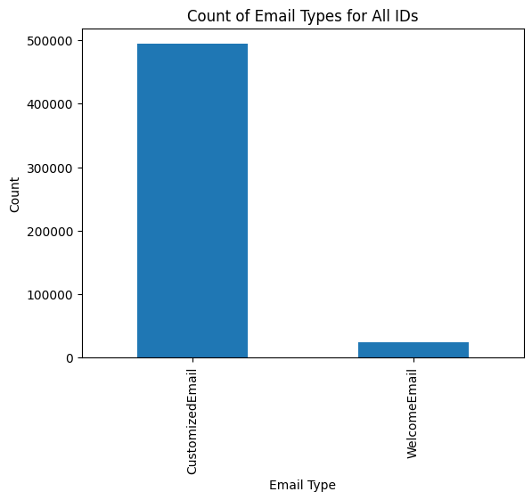

```python
email_df.groupby(['EmailType'])['CustomerID'].count().plot(kind='bar')

# set plot title and labels
plt.title('Count of Email Types for All IDs')
plt.xlabel('Email Type')
plt.ylabel('Count')

# show the plot
plt.show()
```

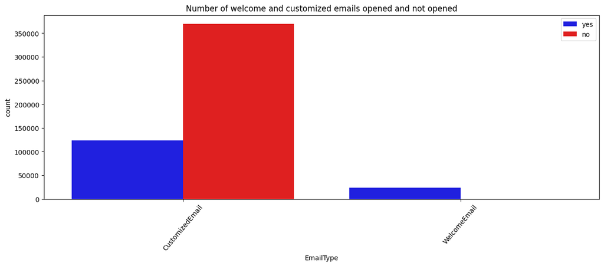

```python
# Observing the number of emails opened and not opened.
a=Counter(email_df['MailOpened'])
plt.figure(figsize=(15,5))
plt.xticks(fontsize=10, rotation=50)
plt.title('Number of welcome and customized emails opened and not opened')
sns.countplot(x ='EmailType', data=email_df, hue='MailOpened', order = email_df['EmailType'].value_counts().index,palette=['blue','red'])
plt.legend(loc='upper right')
```

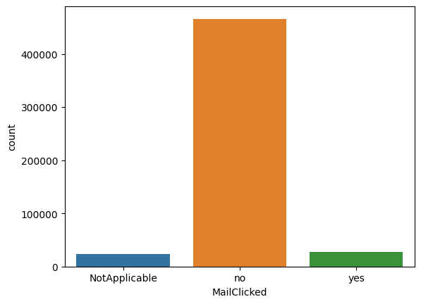

```python
sns.countplot(x='MailClicked', data=email_df)
plt.show()
```

```python
# Define the function to calculate new column(welcome email opened or not)
def is_welcome_opened(row):
    if row['EmailType'] == 'WelcomeEmail' and row['MailOpened'] == 'yes':
        return 1  #yes =1
    else:
        return 1  #no=1
```

```python
# Calculate the welcome email opened or not column
email_df1 = pd.DataFrame()
email_df1['CustomerID'] = email_df['CustomerID'].unique()
email_df1['welcome_email_opened'] = email_df.apply(is_welcome_opened, axis=1)

# Display the email_df1 DataFrame
email_df1
```

|  | CustomerID | welcome_email_opened |
| --- | --- | --- |
| 0 | C16368 | 1 |
| 1 | C20345 | 1 |
| 2 | C17683 | 1 |
| 3 | C18647 | 1 |
| 4 | C36692 | 1 |
| ... | ... | ... |
| 23815 | C23511 | 1 |
| 23816 | C12197 | 1 |
| 23817 | C40967 | 1 |
| 23818 | C36140 | 1 |
| 23819 | C42003 | 1 |

23820 rows × 2 columns

```python
#creating new email_df2
email_df2 = email_df.groupby('CustomerID').agg(
    no_of_customized_email=('EmailType', lambda x: (x == 'CustomizedEmail').sum()),
    no_of_customized_email_opened=('MailOpened', lambda x: ((email_df.loc[x.index, 'EmailType'] == 'CustomizedEmail') & (x == 'yes')).sum()),
    no_of_customized_email_clicked=('MailClicked', lambda x: ((email_df.loc[x.index, 'EmailType'] == 'CustomizedEmail') & (x == 'yes')).sum())
).reset_index()

# Display the new DataFrame
email_df2
```

|  | CustomerID | no_of_customized_email | no_of_customized_email_opened | no_of_customized_email_clicked |
| --- | --- | --- | --- | --- |
| 0 | C12116 | 31 | 4 | 2 |
| 1 | C12117 | 0 | 0 | 0 |
| 2 | C12118 | 0 | 0 | 0 |
| 3 | C12119 | 41 | 13 | 4 |
| 4 | C12120 | 0 | 0 | 0 |
| ... | ... | ... | ... | ... |
| 23815 | C42185 | 43 | 9 | 0 |
| 23816 | C42186 | 0 | 0 | 0 |
| 23817 | C42187 | 0 | 0 | 0 |
| 23818 | C42188 | 0 | 0 | 0 |
| 23819 | C42189 | 50 | 18 | 0 |

23820 rows × 4 columns

```python
#merging email_df1 and email_df2 based on CustomerID
clean_email_df= pd.merge(email_df1, email_df2, on='CustomerID')
clean_email_df
```

|  | CustomerID | welcome_email_opened | no_of_customized_email | no_of_customized_email_opened | no_of_customized_email_clicked |
| --- | --- | --- | --- | --- | --- |
| 0 | C16368 | 1 | 29 | 29 | 1 |
| 1 | C20345 | 1 | 95 | 88 | 10 |
| 2 | C17683 | 1 | 0 | 0 | 0 |
| 3 | C18647 | 1 | 30 | 27 | 4 |
| 4 | C36692 | 1 | 64 | 18 | 10 |
| ... | ... | ... | ... | ... | ... |
| 23815 | C23511 | 1 | 0 | 0 | 0 |
| 23816 | C12197 | 1 | 0 | 0 | 0 |
| 23817 | C40967 | 1 | 0 | 0 | 0 |
| 23818 | C36140 | 1 | 8 | 6 | 3 |
| 23819 | C42003 | 1 | 0 | 0 | 0 |

23820 rows × 5 columns

## transaction_df

```python
transaction_df
```

|  | CustomerID | DateOfOrder | timestamp | OrderQuantity |
| --- | --- | --- | --- | --- |
| 0 | C16368 | 2013-08-11 | 15:17:52 | 15 |
| 1 | C20345 | 2011-04-01 | 19:50:00 | 92 |
| 2 | C20345 | 2012-06-29 | 15:11:56 | 95 |
| 3 | C20345 | 2012-09-22 | 20:49:10 | 74 |
| 4 | C20345 | 2011-08-23 | 11:50:26 | 81 |
| ... | ... | ... | ... | ... |
| 104750 | C12197 | 2018-01-17 | 14:35:40 | 56 |
| 104751 | C40967 | 2018-01-17 | 17:15:20 | 35 |
| 104752 | C36140 | 2018-01-17 | 13:12:54 | 47 |
| 104753 | C36140 | 2018-01-21 | 21:12:52 | 53 |
| 104754 | C42003 | 2018-01-17 | 16:34:46 | 41 |

104755 rows × 4 columns

```python
transaction_df1=transaction_df.loc[:, ["CustomerID", "DateOfOrder"]]
transaction_df1
```

|  | CustomerID | DateOfOrder |
| --- | --- | --- |
| 0 | C16368 | 2013-08-11 |
| 1 | C20345 | 2011-04-01 |
| 2 | C20345 | 2012-06-29 |
| 3 | C20345 | 2012-09-22 |
| 4 | C20345 | 2011-08-23 |
| ... | ... | ... |
| 104750 | C12197 | 2018-01-17 |
| 104751 | C40967 | 2018-01-17 |
| 104752 | C36140 | 2018-01-17 |
| 104753 | C36140 | 2018-01-21 |
| 104754 | C42003 | 2018-01-17 |

104755 rows × 2 columns

```python
transaction_df2=transaction_df.loc[:, ["CustomerID", "OrderQuantity"]]
transaction_df2
```

|  | CustomerID | OrderQuantity |
| --- | --- | --- |
| 0 | C16368 | 15 |
| 1 | C20345 | 92 |
| 2 | C20345 | 95 |
| 3 | C20345 | 74 |
| 4 | C20345 | 81 |
| ... | ... | ... |
| 104750 | C12197 | 56 |
| 104751 | C40967 | 35 |
| 104752 | C36140 | 47 |
| 104753 | C36140 | 53 |
| 104754 | C42003 | 41 |

104755 rows × 2 columns

```python
transaction_df3=transaction_df.loc[:, ["CustomerID", "DateOfOrder"]]
transaction_df3
```

|  | CustomerID | DateOfOrder |
| --- | --- | --- |
| 0 | C16368 | 2013-08-11 |
| 1 | C20345 | 2011-04-01 |
| 2 | C20345 | 2012-06-29 |
| 3 | C20345 | 2012-09-22 |
| 4 | C20345 | 2011-08-23 |
| ... | ... | ... |
| 104750 | C12197 | 2018-01-17 |
| 104751 | C40967 | 2018-01-17 |
| 104752 | C36140 | 2018-01-17 |
| 104753 | C36140 | 2018-01-21 |
| 104754 | C42003 | 2018-01-17 |

104755 rows × 2 columns

```python
transaction_df1['DateOfOrder'] = pd.to_datetime(transaction_df1['DateOfOrder'])
transaction_df1 =transaction_df1.sort_values(['CustomerID', 'DateOfOrder'])
transaction_df1.head()
```

|  | CustomerID | DateOfOrder |
| --- | --- | --- |
| 73908 | C12116 | 2013-10-03 |
| 73909 | C12116 | 2013-10-08 |
| 73910 | C12116 | 2013-10-10 |
| 81596 | C12117 | 2013-12-05 |
| 71421 | C12118 | 2013-09-10 |

```python
#creating ordergap column
transaction_df1['OrderGap'] = transaction_df1.groupby('CustomerID')['DateOfOrder'].diff().fillna(pd.Timedelta(seconds=0))
transaction_df1.head()
```

|  | CustomerID | DateOfOrder | OrderGap |
| --- | --- | --- | --- |
| 73908 | C12116 | 2013-10-03 | 0 days |
| 73909 | C12116 | 2013-10-08 | 5 days |
| 73910 | C12116 | 2013-10-10 | 2 days |
| 81596 | C12117 | 2013-12-05 | 0 days |
| 71421 | C12118 | 2013-09-10 | 0 days |

```python
#removinng days string from OrderGap
transaction_df1['OrderGap'] = (transaction_df1['OrderGap'].dt.total_seconds() / 86400).astype(int)
transaction_df1.head()
```

|  | CustomerID | DateOfOrder | OrderGap |
| --- | --- | --- | --- |
| 73908 | C12116 | 2013-10-03 | 0 |
| 73909 | C12116 | 2013-10-08 | 5 |
| 73910 | C12116 | 2013-10-10 | 2 |
| 81596 | C12117 | 2013-12-05 | 0 |
| 71421 | C12118 | 2013-09-10 | 0 |

```python
transaction_df1 = transaction_df1.groupby('CustomerID')['OrderGap'].mean().reset_index()
transaction_df1.columns = ['CustomerID', 'Average_Ordergap']
transaction_df1.head()
```

|  | CustomerID | Average_Ordergap |
| --- | --- | --- |
| 0 | C12116 | 2.333333 |
| 1 | C12117 | 0.000000 |
| 2 | C12118 | 0.000000 |
| 3 | C12119 | 0.000000 |
| 4 | C12120 | 0.000000 |

```python
# group by ID and aggregate the order quantity by sum
transaction_df2 = transaction_df2.groupby('CustomerID')['OrderQuantity'].agg(['sum', 'count']).reset_index()

# rename the columns
transaction_df2 = transaction_df2.rename(columns={'sum': 'TotalOrderQuantity', 'count': 'OrderFrequency'})

# print the new DataFrame
transaction_df2
```

|  | CustomerID | TotalOrderQuantity | OrderFrequency |
| --- | --- | --- | --- |
| 0 | C12116 | 115 | 3 |
| 1 | C12117 | 41 | 1 |
| 2 | C12118 | 41 | 1 |
| 3 | C12119 | 52 | 1 |
| 4 | C12120 | 31 | 1 |
| ... | ... | ... | ... |
| 23815 | C42185 | 1340 | 13 |
| 23816 | C42186 | 46 | 1 |
| 23817 | C42187 | 41 | 1 |
| 23818 | C42188 | 51 | 1 |
| 23819 | C42189 | 180 | 2 |

23820 rows × 3 columns

```python
# Convert dateoforder to datetime format
transaction_df3['DateOfOrder'] = pd.to_datetime(transaction_df3['DateOfOrder'])

# Group the transactions by 'id' and extract the first and last order dates for each group
first_order = transaction_df3.groupby('CustomerID')['DateOfOrder'].min().reset_index()
last_order = transaction_df3.groupby('CustomerID')['DateOfOrder'].max().reset_index()

# Merge the first_order and last_order DataFrames
transaction_df3 = pd.merge(first_order, last_order, on='CustomerID')

# Rename the columns
transaction_df3.columns = ['CustomerID', 'firstOrder', 'lastOrder']

# Print the result
transaction_df3
```

|  | CustomerID | firstOrder | lastOrder |
| --- | --- | --- | --- |
| 0 | C12116 | 2013-10-03 | 2013-10-10 |
| 1 | C12117 | 2013-12-05 | 2013-12-05 |
| 2 | C12118 | 2013-09-10 | 2013-09-10 |
| 3 | C12119 | 2013-10-22 | 2013-10-22 |
| 4 | C12120 | 2014-01-10 | 2014-01-10 |
| ... | ... | ... | ... |
| 23815 | C42185 | 2011-04-04 | 2012-01-03 |
| 23816 | C42186 | 2013-11-23 | 2013-11-23 |
| 23817 | C42187 | 2013-09-15 | 2013-09-15 |
| 23818 | C42188 | 2011-10-04 | 2011-10-04 |
| 23819 | C42189 | 2013-05-09 | 2013-11-15 |

23820 rows × 3 columns

```python
merged_transaction_df= pd.merge(transaction_df2, transaction_df1, on='CustomerID')
clean_transaction_df= pd.merge(merged_transaction_df, transaction_df3, on='CustomerID')
clean_transaction_df
```

|  | CustomerID | TotalOrderQuantity | OrderFrequency | Average_Ordergap | firstOrder | lastOrder |
| --- | --- | --- | --- | --- | --- | --- |
| 0 | C12116 | 115 | 3 | 2.333333 | 2013-10-03 | 2013-10-10 |
| 1 | C12117 | 41 | 1 | 0.000000 | 2013-12-05 | 2013-12-05 |
| 2 | C12118 | 41 | 1 | 0.000000 | 2013-09-10 | 2013-09-10 |
| 3 | C12119 | 52 | 1 | 0.000000 | 2013-10-22 | 2013-10-22 |
| 4 | C12120 | 31 | 1 | 0.000000 | 2014-01-10 | 2014-01-10 |
| ... | ... | ... | ... | ... | ... | ... |
| 23815 | C42185 | 1340 | 13 | 21.076923 | 2011-04-04 | 2012-01-03 |
| 23816 | C42186 | 46 | 1 | 0.000000 | 2013-11-23 | 2013-11-23 |
| 23817 | C42187 | 41 | 1 | 0.000000 | 2013-09-15 | 2013-09-15 |
| 23818 | C42188 | 51 | 1 | 0.000000 | 2011-10-04 | 2011-10-04 |
| 23819 | C42189 | 180 | 2 | 95.000000 | 2013-05-09 | 2013-11-15 |

23820 rows × 6 columns

## Merging 4 dataframes

```python
merged_df1 = pd.merge(customer_df,clean_email_df, on='CustomerID')
merged_df2 = pd.merge(merged_df1, clean_transaction_df, on='CustomerID')
final_merged_df = pd.merge(train_df1,merged_df2 , on='CustomerID')
final_merged_df
```

|  | CustomerID | RetentionPotential | City | DateOfRegistration | OnlineCommunication | AutomaticRefill | DoorstepDelivery | PreferredDeliveryDay | welcome_email_opened | no_of_customized_email | no_of_customized_email_opened | no_of_customized_email_clicked | TotalOrderQuantity | OrderFrequency | Average_Ordergap | firstOrder | lastOrder |
| --- | --- | --- | --- | --- | --- | --- | --- | --- | --- | --- | --- | --- | --- | --- | --- | --- | --- |
| 0 | C37869 | Low | CITY4 | 2011-07-27 | 0 | 0 | 0 | Thursday | 1 | 47 | 3 | 0 | 982 | 8 | 95.500000 | 2011-07-27 | 2013-08-29 |
| 1 | C33841 | Low | CITY1 | 2013-11-19 | 1 | 0 | 1 | Thursday | 1 | 10 | 6 | 2 | 43 | 1 | 0.000000 | 2013-12-23 | 2013-12-23 |
| 2 | C29464 | Low | CITY2 | 2010-05-24 | 0 | 0 | 0 | Tuesday | 1 | 0 | 0 | 0 | 51 | 1 | 0.000000 | 2010-05-24 | 2010-05-24 |
| 3 | C28158 | Low | CITY1 | 2017-06-19 | 1 | 0 | 0 | Saturday | 1 | 0 | 0 | 0 | 60 | 1 | 0.000000 | 2017-06-19 | 2017-06-19 |
| 4 | C22785 | High | CITY2 | 2013-12-13 | 1 | 0 | 0 | Thursday | 1 | 0 | 0 | 0 | 41 | 1 | 0.000000 | 2013-12-13 | 2013-12-13 |
| ... | ... | ... | ... | ... | ... | ... | ... | ... | ... | ... | ... | ... | ... | ... | ... | ... | ... |
| 23815 | C14975 | Low | CITY4 | 2012-03-28 | 0 | 0 | 0 | Tuesday | 1 | 47 | 0 | 0 | 57 | 5 | 14.000000 | 2012-04-13 | 2012-06-22 |
| 23816 | C30392 | Low | CITY2 | 2011-01-26 | 0 | 0 | 0 | Monday | 1 | 46 | 6 | 0 | 662 | 12 | 31.666667 | 2011-03-12 | 2012-03-26 |
| 23817 | C41735 | Low | CITY3 | 2013-09-21 | 1 | 0 | 0 | Wednesday | 1 | 37 | 19 | 5 | 29 | 1 | 0.000000 | 2013-10-10 | 2013-10-10 |
| 23818 | C26055 | Low | CITY4 | 2013-11-23 | 1 | 0 | 0 | Friday | 1 | 26 | 6 | 3 | 55 | 1 | 0.000000 | 2013-12-01 | 2013-12-01 |
| 23819 | C25058 | High | CITY4 | 2011-11-16 | 0 | 0 | 0 | Tuesday | 1 | 0 | 0 | 0 | 52 | 1 | 0.000000 | 2011-11-16 | 2011-11-16 |

23820 rows × 17 columns

## Feature Engineering

**no_of_DayswithBusiness**: The duration of a customer's relationship with the business in terms of days.

**no_of_MakingBusinessDays**: Duration of time in which a customer made orders from the business, in terms of days.

```python
# Calculate the differences in days and add them as new columns
final_merged_df['no_of_DayswithBusiness'] = (final_merged_df['lastOrder'] - final_merged_df['DateOfRegistration']).dt.days.abs()
final_merged_df['no_of_MakingBusinessDays'] = (final_merged_df['lastOrder'] - final_merged_df['firstOrder']).dt.days.abs()
final_merged_df
```

|  | CustomerID | RetentionPotential | City | DateOfRegistration | OnlineCommunication | AutomaticRefill | DoorstepDelivery | PreferredDeliveryDay | welcome_email_opened | no_of_customized_email | no_of_customized_email_opened | no_of_customized_email_clicked | TotalOrderQuantity | OrderFrequency | Average_Ordergap | firstOrder | lastOrder | no_of_DayswithBusiness | no_of_MakingBusinessDays |
| --- | --- | --- | --- | --- | --- | --- | --- | --- | --- | --- | --- | --- | --- | --- | --- | --- | --- | --- | --- |
| 0 | C37869 | Low | CITY4 | 2011-07-27 | 0 | 0 | 0 | Thursday | 1 | 47 | 3 | 0 | 982 | 8 | 95.500000 | 2011-07-27 | 2013-08-29 | 764 | 764 |
| 1 | C33841 | Low | CITY1 | 2013-11-19 | 1 | 0 | 1 | Thursday | 1 | 10 | 6 | 2 | 43 | 1 | 0.000000 | 2013-12-23 | 2013-12-23 | 34 | 0 |
| 2 | C29464 | Low | CITY2 | 2010-05-24 | 0 | 0 | 0 | Tuesday | 1 | 0 | 0 | 0 | 51 | 1 | 0.000000 | 2010-05-24 | 2010-05-24 | 0 | 0 |
| 3 | C28158 | Low | CITY1 | 2017-06-19 | 1 | 0 | 0 | Saturday | 1 | 0 | 0 | 0 | 60 | 1 | 0.000000 | 2017-06-19 | 2017-06-19 | 0 | 0 |
| 4 | C22785 | High | CITY2 | 2013-12-13 | 1 | 0 | 0 | Thursday | 1 | 0 | 0 | 0 | 41 | 1 | 0.000000 | 2013-12-13 | 2013-12-13 | 0 | 0 |
| ... | ... | ... | ... | ... | ... | ... | ... | ... | ... | ... | ... | ... | ... | ... | ... | ... | ... | ... | ... |
| 23815 | C14975 | Low | CITY4 | 2012-03-28 | 0 | 0 | 0 | Tuesday | 1 | 47 | 0 | 0 | 57 | 5 | 14.000000 | 2012-04-13 | 2012-06-22 | 86 | 70 |
| 23816 | C30392 | Low | CITY2 | 2011-01-26 | 0 | 0 | 0 | Monday | 1 | 46 | 6 | 0 | 662 | 12 | 31.666667 | 2011-03-12 | 2012-03-26 | 425 | 380 |
| 23817 | C41735 | Low | CITY3 | 2013-09-21 | 1 | 0 | 0 | Wednesday | 1 | 37 | 19 | 5 | 29 | 1 | 0.000000 | 2013-10-10 | 2013-10-10 | 19 | 0 |
| 23818 | C26055 | Low | CITY4 | 2013-11-23 | 1 | 0 | 0 | Friday | 1 | 26 | 6 | 3 | 55 | 1 | 0.000000 | 2013-12-01 | 2013-12-01 | 8 | 0 |
| 23819 | C25058 | High | CITY4 | 2011-11-16 | 0 | 0 | 0 | Tuesday | 1 | 0 | 0 | 0 | 52 | 1 | 0.000000 | 2011-11-16 | 2011-11-16 | 0 | 0 |

23820 rows × 19 columns

```python
Train_df=final_merged_df.drop(['DateOfRegistration','firstOrder','lastOrder'],axis=1)
Train_df
```

|  | CustomerID | RetentionPotential | City | OnlineCommunication | AutomaticRefill | DoorstepDelivery | PreferredDeliveryDay | welcome_email_opened | no_of_customized_email | no_of_customized_email_opened | no_of_customized_email_clicked | TotalOrderQuantity | OrderFrequency | Average_Ordergap | no_of_DayswithBusiness | no_of_MakingBusinessDays |
| --- | --- | --- | --- | --- | --- | --- | --- | --- | --- | --- | --- | --- | --- | --- | --- | --- |
| 0 | C37869 | Low | CITY4 | 0 | 0 | 0 | Thursday | 1 | 47 | 3 | 0 | 982 | 8 | 95.500000 | 764 | 764 |
| 1 | C33841 | Low | CITY1 | 1 | 0 | 1 | Thursday | 1 | 10 | 6 | 2 | 43 | 1 | 0.000000 | 34 | 0 |
| 2 | C29464 | Low | CITY2 | 0 | 0 | 0 | Tuesday | 1 | 0 | 0 | 0 | 51 | 1 | 0.000000 | 0 | 0 |
| 3 | C28158 | Low | CITY1 | 1 | 0 | 0 | Saturday | 1 | 0 | 0 | 0 | 60 | 1 | 0.000000 | 0 | 0 |
| 4 | C22785 | High | CITY2 | 1 | 0 | 0 | Thursday | 1 | 0 | 0 | 0 | 41 | 1 | 0.000000 | 0 | 0 |
| ... | ... | ... | ... | ... | ... | ... | ... | ... | ... | ... | ... | ... | ... | ... | ... | ... |
| 23815 | C14975 | Low | CITY4 | 0 | 0 | 0 | Tuesday | 1 | 47 | 0 | 0 | 57 | 5 | 14.000000 | 86 | 70 |
| 23816 | C30392 | Low | CITY2 | 0 | 0 | 0 | Monday | 1 | 46 | 6 | 0 | 662 | 12 | 31.666667 | 425 | 380 |
| 23817 | C41735 | Low | CITY3 | 1 | 0 | 0 | Wednesday | 1 | 37 | 19 | 5 | 29 | 1 | 0.000000 | 19 | 0 |
| 23818 | C26055 | Low | CITY4 | 1 | 0 | 0 | Friday | 1 | 26 | 6 | 3 | 55 | 1 | 0.000000 | 8 | 0 |
| 23819 | C25058 | High | CITY4 | 0 | 0 | 0 | Tuesday | 1 | 0 | 0 | 0 | 52 | 1 | 0.000000 | 0 | 0 |

23820 rows × 16 columns

```python
Train_df.describe()
```

|  | OnlineCommunication | AutomaticRefill | DoorstepDelivery | welcome_email_opened | no_of_customized_email | no_of_customized_email_opened | no_of_customized_email_clicked | TotalOrderQuantity | OrderFrequency | Average_Ordergap | no_of_DayswithBusiness | no_of_MakingBusinessDays |
| --- | --- | --- | --- | --- | --- | --- | --- | --- | --- | --- | --- | --- |
| count | 23820.000000 | 23820.000000 | 23820.000000 | 23820.0 | 23820.000000 | 23820.000000 | 23820.000000 | 23820.000000 | 23820.000000 | 23820.000000 | 23820.000000 | 23820.000000 |
| mean | 0.660411 | 0.094710 | 0.037615 | 1.0 | 20.732662 | 5.207389 | 1.168808 | 357.622922 | 4.397775 | 12.527876 | 129.325441 | 86.941352 |
| std | 0.473580 | 0.292821 | 0.190268 | 0.0 | 20.040546 | 8.517405 | 2.376062 | 1335.649680 | 12.142475 | 36.102332 | 266.695842 | 220.576316 |
| min | 0.000000 | 0.000000 | 0.000000 | 1.0 | 0.000000 | 0.000000 | 0.000000 | 0.000000 | 1.000000 | 0.000000 | 0.000000 | 0.000000 |
| 25% | 0.000000 | 0.000000 | 0.000000 | 1.0 | 0.000000 | 0.000000 | 0.000000 | 41.000000 | 1.000000 | 0.000000 | 0.000000 | 0.000000 |
| 50% | 1.000000 | 0.000000 | 0.000000 | 1.0 | 19.000000 | 1.000000 | 0.000000 | 65.000000 | 1.000000 | 0.000000 | 16.000000 | 0.000000 |
| 75% | 1.000000 | 0.000000 | 0.000000 | 1.0 | 40.000000 | 7.000000 | 1.000000 | 169.000000 | 3.000000 | 10.000000 | 102.000000 | 42.000000 |
| max | 1.000000 | 1.000000 | 1.000000 | 1.0 | 291.000000 | 255.000000 | 42.000000 | 51429.000000 | 257.000000 | 807.500000 | 1998.000000 | 1985.000000 |

## Visualizations after merging

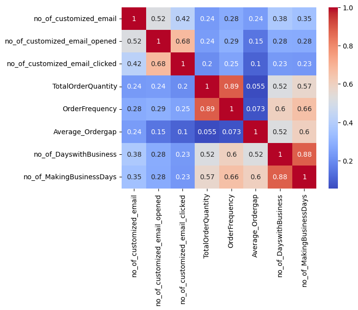

```python
# select columns to include in heatmap
cols = ['no_of_customized_email', 'no_of_customized_email_opened', 'no_of_customized_email_clicked','TotalOrderQuantity','OrderFrequency','Average_Ordergap','no_of_DayswithBusiness','no_of_MakingBusinessDays']

# create heatmap using selected columns
sns.heatmap(Train_df[cols].corr(), annot=True, cmap='coolwarm')

# display the heatmap
plt.show()
```

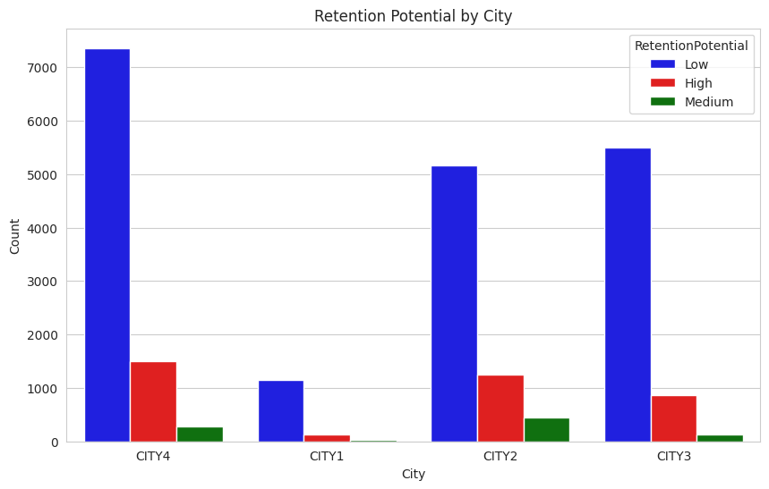

```python
# create a stacked bar chart
sns.set_style('whitegrid')
plt.figure(figsize=(10, 6))
sns.countplot(x='City', hue='RetentionPotential', data=final_merged_df, palette=['blue', 'red', 'green'])
plt.title('Retention Potential by City')
plt.xlabel('City')
plt.ylabel('Count')
plt.show()
```

INSIGHTS

Here In city2,city4,city3 more customers has the low RetentionPotential

```
Counter({'Tuesday': 5343, 'Monday': 5300, 'Friday': 4167, 'Thursday': 4043, 'Wednesday': 3778, 'Saturday': 1003, 'Sunday': 186})
```

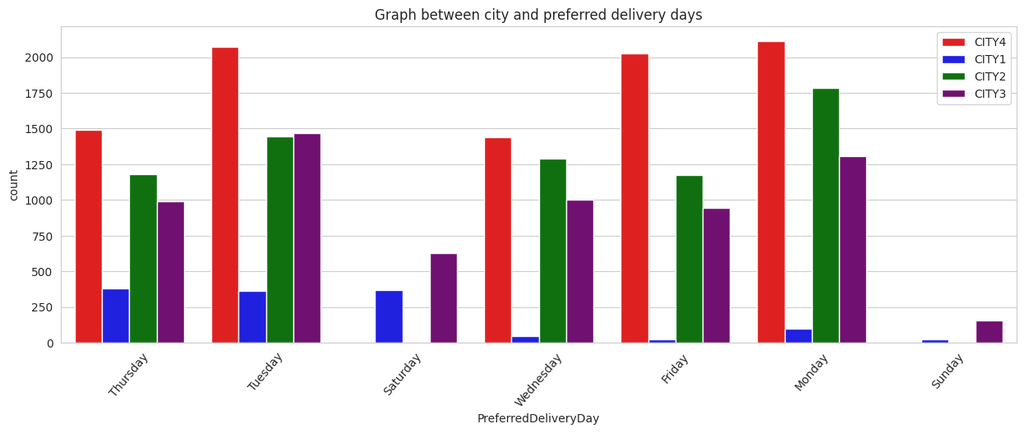

```python
# Observing the PreferredDeliveryDay.
a = Counter(final_merged_df['PreferredDeliveryDay'])
print(a)
plt.figure(figsize=(15,5))
plt.xticks(fontsize=10, rotation=50)
plt.title('Graph between city and preferred delivery days')
sns.countplot(x ='PreferredDeliveryDay', data=final_merged_df, hue='City', palette=['red','blue','green','purple'])
plt.legend(loc='upper right')
plt.show()
```

Here by observing the preferred deliverydays, Customers buying online pefer more on weekdays and less in weekends.

## Encoding

```python
cat_cols=["City", "PreferredDeliveryDay"]

# Convert categorical columns into dummy variables
df_dummies = pd.get_dummies(Train_df[cat_cols],columns=cat_cols, drop_first=True)

# Concatenate the dummy variables with the original dataframe
Train_df = pd.concat([Train_df, df_dummies], axis=1)

# Drop the original categorical columns
Train_df.drop(columns=cat_cols, inplace=True)

# Print the updated dataframe
Train_df.head()
```

|  | CustomerID | RetentionPotential | OnlineCommunication | AutomaticRefill | DoorstepDelivery | welcome_email_opened | no_of_customized_email | no_of_customized_email_opened | no_of_customized_email_clicked | TotalOrderQuantity | OrderFrequency | Average_Ordergap | no_of_DayswithBusiness | no_of_MakingBusinessDays | City_CITY2 | City_CITY3 | City_CITY4 | PreferredDeliveryDay_Monday | PreferredDeliveryDay_Saturday | PreferredDeliveryDay_Sunday | PreferredDeliveryDay_Thursday | PreferredDeliveryDay_Tuesday | PreferredDeliveryDay_Wednesday |
| --- | --- | --- | --- | --- | --- | --- | --- | --- | --- | --- | --- | --- | --- | --- | --- | --- | --- | --- | --- | --- | --- | --- | --- |
| 0 | C37869 | Low | 0 | 0 | 0 | 1 | 47 | 3 | 0 | 982 | 8 | 95.5 | 764 | 764 | 0 | 0 | 1 | 0 | 0 | 0 | 1 | 0 | 0 |
| 1 | C33841 | Low | 1 | 0 | 1 | 1 | 10 | 6 | 2 | 43 | 1 | 0.0 | 34 | 0 | 0 | 0 | 0 | 0 | 0 | 0 | 1 | 0 | 0 |
| 2 | C29464 | Low | 0 | 0 | 0 | 1 | 0 | 0 | 0 | 51 | 1 | 0.0 | 0 | 0 | 1 | 0 | 0 | 0 | 0 | 0 | 0 | 1 | 0 |
| 3 | C28158 | Low | 1 | 0 | 0 | 1 | 0 | 0 | 0 | 60 | 1 | 0.0 | 0 | 0 | 0 | 0 | 0 | 0 | 1 | 0 | 0 | 0 | 0 |
| 4 | C22785 | High | 1 | 0 | 0 | 1 | 0 | 0 | 0 | 41 | 1 | 0.0 | 0 | 0 | 1 | 0 | 0 | 0 | 0 | 0 | 1 | 0 | 0 |

```python
Train_df.shape
```

```
(23820, 23)
```

```python
#labelencoding for the target column
from sklearn.preprocessing import LabelEncoder
# Create a LabelEncoder object
le = LabelEncoder()

# Fit and transform the 'city' column
Train_df['RetentionPotential'] = le.fit_transform(Train_df['RetentionPotential'])

# Print the result
Train_df
```

|  | CustomerID | RetentionPotential | OnlineCommunication | AutomaticRefill | DoorstepDelivery | welcome_email_opened | no_of_customized_email | no_of_customized_email_opened | no_of_customized_email_clicked | TotalOrderQuantity | OrderFrequency | Average_Ordergap | no_of_DayswithBusiness | no_of_MakingBusinessDays | City_CITY2 | City_CITY3 | City_CITY4 | PreferredDeliveryDay_Monday | PreferredDeliveryDay_Saturday | PreferredDeliveryDay_Sunday | PreferredDeliveryDay_Thursday | PreferredDeliveryDay_Tuesday | PreferredDeliveryDay_Wednesday |
| --- | --- | --- | --- | --- | --- | --- | --- | --- | --- | --- | --- | --- | --- | --- | --- | --- | --- | --- | --- | --- | --- | --- | --- |
| 0 | C37869 | 1 | 0 | 0 | 0 | 1 | 47 | 3 | 0 | 982 | 8 | 95.500000 | 764 | 764 | 0 | 0 | 1 | 0 | 0 | 0 | 1 | 0 | 0 |
| 1 | C33841 | 1 | 1 | 0 | 1 | 1 | 10 | 6 | 2 | 43 | 1 | 0.000000 | 34 | 0 | 0 | 0 | 0 | 0 | 0 | 0 | 1 | 0 | 0 |
| 2 | C29464 | 1 | 0 | 0 | 0 | 1 | 0 | 0 | 0 | 51 | 1 | 0.000000 | 0 | 0 | 1 | 0 | 0 | 0 | 0 | 0 | 0 | 1 | 0 |
| 3 | C28158 | 1 | 1 | 0 | 0 | 1 | 0 | 0 | 0 | 60 | 1 | 0.000000 | 0 | 0 | 0 | 0 | 0 | 0 | 1 | 0 | 0 | 0 | 0 |
| 4 | C22785 | 0 | 1 | 0 | 0 | 1 | 0 | 0 | 0 | 41 | 1 | 0.000000 | 0 | 0 | 1 | 0 | 0 | 0 | 0 | 0 | 1 | 0 | 0 |
| ... | ... | ... | ... | ... | ... | ... | ... | ... | ... | ... | ... | ... | ... | ... | ... | ... | ... | ... | ... | ... | ... | ... | ... |
| 23815 | C14975 | 1 | 0 | 0 | 0 | 1 | 47 | 0 | 0 | 57 | 5 | 14.000000 | 86 | 70 | 0 | 0 | 1 | 0 | 0 | 0 | 0 | 1 | 0 |
| 23816 | C30392 | 1 | 0 | 0 | 0 | 1 | 46 | 6 | 0 | 662 | 12 | 31.666667 | 425 | 380 | 1 | 0 | 0 | 1 | 0 | 0 | 0 | 0 | 0 |
| 23817 | C41735 | 1 | 1 | 0 | 0 | 1 | 37 | 19 | 5 | 29 | 1 | 0.000000 | 19 | 0 | 0 | 1 | 0 | 0 | 0 | 0 | 0 | 0 | 1 |
| 23818 | C26055 | 1 | 1 | 0 | 0 | 1 | 26 | 6 | 3 | 55 | 1 | 0.000000 | 8 | 0 | 0 | 0 | 1 | 0 | 0 | 0 | 0 | 0 | 0 |
| 23819 | C25058 | 0 | 0 | 0 | 0 | 1 | 0 | 0 | 0 | 52 | 1 | 0.000000 | 0 | 0 | 0 | 0 | 1 | 0 | 0 | 0 | 0 | 1 | 0 |

23820 rows × 23 columns

## checking skewness

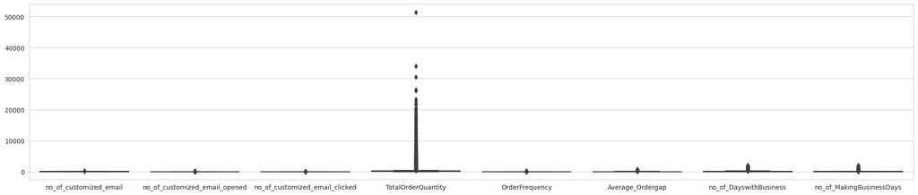

```python
# select columns to plot
columns_to_plot = ['no_of_customized_email', 'no_of_customized_email_opened', 'no_of_customized_email_clicked','TotalOrderQuantity','OrderFrequency','Average_Ordergap','no_of_DayswithBusiness','no_of_MakingBusinessDays']

# plot box plots for selected columns
plt.figure(figsize=(25, 5))
sns.boxplot(data=Train_df[columns_to_plot])
```

```python
for column in ['TotalOrderQuantity', 'no_of_DayswithBusiness', 'no_of_MakingBusinessDays']:
    skewness = Train_df[column].skew()
    print(f"The skewness of {column} is {skewness:.2f}")
```

```
The skewness of TotalOrderQuantity is 11.27
The skewness of no_of_DayswithBusiness is 2.93
The skewness of no_of_MakingBusinessDays is 3.39
```

```python
Train_df['TotalOrderQuantity'] = np.sqrt(Train_df['TotalOrderQuantity'])
Train_df['no_of_DayswithBusiness'] = np.sqrt(Train_df['no_of_DayswithBusiness'])
Train_df['no_of_MakingBusinessDays'] = np.sqrt(Train_df['no_of_MakingBusinessDays'])
```

```python
Train_df
```

|  | CustomerID | RetentionPotential | OnlineCommunication | AutomaticRefill | DoorstepDelivery | welcome_email_opened | no_of_customized_email | no_of_customized_email_opened | no_of_customized_email_clicked | TotalOrderQuantity | OrderFrequency | Average_Ordergap | no_of_DayswithBusiness | no_of_MakingBusinessDays | City_CITY2 | City_CITY3 | City_CITY4 | PreferredDeliveryDay_Monday | PreferredDeliveryDay_Saturday | PreferredDeliveryDay_Sunday | PreferredDeliveryDay_Thursday | PreferredDeliveryDay_Tuesday | PreferredDeliveryDay_Wednesday |
| --- | --- | --- | --- | --- | --- | --- | --- | --- | --- | --- | --- | --- | --- | --- | --- | --- | --- | --- | --- | --- | --- | --- | --- |
| 0 | C37869 | 1 | 0 | 0 | 0 | 1 | 47 | 3 | 0 | 31.336879 | 8 | 95.500000 | 27.640550 | 27.640550 | 0 | 0 | 1 | 0 | 0 | 0 | 1 | 0 | 0 |
| 1 | C33841 | 1 | 1 | 0 | 1 | 1 | 10 | 6 | 2 | 6.557439 | 1 | 0.000000 | 5.830952 | 0.000000 | 0 | 0 | 0 | 0 | 0 | 0 | 1 | 0 | 0 |
| 2 | C29464 | 1 | 0 | 0 | 0 | 1 | 0 | 0 | 0 | 7.141428 | 1 | 0.000000 | 0.000000 | 0.000000 | 1 | 0 | 0 | 0 | 0 | 0 | 0 | 1 | 0 |
| 3 | C28158 | 1 | 1 | 0 | 0 | 1 | 0 | 0 | 0 | 7.745967 | 1 | 0.000000 | 0.000000 | 0.000000 | 0 | 0 | 0 | 0 | 1 | 0 | 0 | 0 | 0 |
| 4 | C22785 | 0 | 1 | 0 | 0 | 1 | 0 | 0 | 0 | 6.403124 | 1 | 0.000000 | 0.000000 | 0.000000 | 1 | 0 | 0 | 0 | 0 | 0 | 1 | 0 | 0 |
| ... | ... | ... | ... | ... | ... | ... | ... | ... | ... | ... | ... | ... | ... | ... | ... | ... | ... | ... | ... | ... | ... | ... | ... |
| 23815 | C14975 | 1 | 0 | 0 | 0 | 1 | 47 | 0 | 0 | 7.549834 | 5 | 14.000000 | 9.273618 | 8.366600 | 0 | 0 | 1 | 0 | 0 | 0 | 0 | 1 | 0 |
| 23816 | C30392 | 1 | 0 | 0 | 0 | 1 | 46 | 6 | 0 | 25.729361 | 12 | 31.666667 | 20.615528 | 19.493589 | 1 | 0 | 0 | 1 | 0 | 0 | 0 | 0 | 0 |
| 23817 | C41735 | 1 | 1 | 0 | 0 | 1 | 37 | 19 | 5 | 5.385165 | 1 | 0.000000 | 4.358899 | 0.000000 | 0 | 1 | 0 | 0 | 0 | 0 | 0 | 0 | 1 |
| 23818 | C26055 | 1 | 1 | 0 | 0 | 1 | 26 | 6 | 3 | 7.416198 | 1 | 0.000000 | 2.828427 | 0.000000 | 0 | 0 | 1 | 0 | 0 | 0 | 0 | 0 | 0 |
| 23819 | C25058 | 0 | 0 | 0 | 0 | 1 | 0 | 0 | 0 | 7.211103 | 1 | 0.000000 | 0.000000 | 0.000000 | 0 | 0 | 1 | 0 | 0 | 0 | 0 | 1 | 0 |

23820 rows × 23 columns

```python
Train_df=Train_df.drop("CustomerID",axis=1)
Train_df
```

|  | RetentionPotential | OnlineCommunication | AutomaticRefill | DoorstepDelivery | welcome_email_opened | no_of_customized_email | no_of_customized_email_opened | no_of_customized_email_clicked | TotalOrderQuantity | OrderFrequency | Average_Ordergap | no_of_DayswithBusiness | no_of_MakingBusinessDays | City_CITY2 | City_CITY3 | City_CITY4 | PreferredDeliveryDay_Monday | PreferredDeliveryDay_Saturday | PreferredDeliveryDay_Sunday | PreferredDeliveryDay_Thursday | PreferredDeliveryDay_Tuesday | PreferredDeliveryDay_Wednesday |
| --- | --- | --- | --- | --- | --- | --- | --- | --- | --- | --- | --- | --- | --- | --- | --- | --- | --- | --- | --- | --- | --- | --- |
| 0 | 1 | 0 | 0 | 0 | 1 | 47 | 3 | 0 | 31.336879 | 8 | 95.500000 | 27.640550 | 27.640550 | 0 | 0 | 1 | 0 | 0 | 0 | 1 | 0 | 0 |
| 1 | 1 | 1 | 0 | 1 | 1 | 10 | 6 | 2 | 6.557439 | 1 | 0.000000 | 5.830952 | 0.000000 | 0 | 0 | 0 | 0 | 0 | 0 | 1 | 0 | 0 |
| 2 | 1 | 0 | 0 | 0 | 1 | 0 | 0 | 0 | 7.141428 | 1 | 0.000000 | 0.000000 | 0.000000 | 1 | 0 | 0 | 0 | 0 | 0 | 0 | 1 | 0 |
| 3 | 1 | 1 | 0 | 0 | 1 | 0 | 0 | 0 | 7.745967 | 1 | 0.000000 | 0.000000 | 0.000000 | 0 | 0 | 0 | 0 | 1 | 0 | 0 | 0 | 0 |
| 4 | 0 | 1 | 0 | 0 | 1 | 0 | 0 | 0 | 6.403124 | 1 | 0.000000 | 0.000000 | 0.000000 | 1 | 0 | 0 | 0 | 0 | 0 | 1 | 0 | 0 |
| ... | ... | ... | ... | ... | ... | ... | ... | ... | ... | ... | ... | ... | ... | ... | ... | ... | ... | ... | ... | ... | ... | ... |
| 23815 | 1 | 0 | 0 | 0 | 1 | 47 | 0 | 0 | 7.549834 | 5 | 14.000000 | 9.273618 | 8.366600 | 0 | 0 | 1 | 0 | 0 | 0 | 0 | 1 | 0 |
| 23816 | 1 | 0 | 0 | 0 | 1 | 46 | 6 | 0 | 25.729361 | 12 | 31.666667 | 20.615528 | 19.493589 | 1 | 0 | 0 | 1 | 0 | 0 | 0 | 0 | 0 |
| 23817 | 1 | 1 | 0 | 0 | 1 | 37 | 19 | 5 | 5.385165 | 1 | 0.000000 | 4.358899 | 0.000000 | 0 | 1 | 0 | 0 | 0 | 0 | 0 | 0 | 1 |
| 23818 | 1 | 1 | 0 | 0 | 1 | 26 | 6 | 3 | 7.416198 | 1 | 0.000000 | 2.828427 | 0.000000 | 0 | 0 | 1 | 0 | 0 | 0 | 0 | 0 | 0 |
| 23819 | 0 | 0 | 0 | 0 | 1 | 0 | 0 | 0 | 7.211103 | 1 | 0.000000 | 0.000000 | 0.000000 | 0 | 0 | 1 | 0 | 0 | 0 | 0 | 1 | 0 |

23820 rows × 22 columns

```python
Train_df.columns
```

```
Index(['RetentionPotential', 'OnlineCommunication', 'AutomaticRefill',
       'DoorstepDelivery', 'welcome_email_opened', 'no_of_customized_email',
       'no_of_customized_email_opened', 'no_of_customized_email_clicked',
       'TotalOrderQuantity', 'OrderFrequency', 'Average_Ordergap',
       'no_of_DayswithBusiness', 'no_of_MakingBusinessDays', 'City_CITY2',
       'City_CITY3', 'City_CITY4', 'PreferredDeliveryDay_Monday',
       'PreferredDeliveryDay_Saturday', 'PreferredDeliveryDay_Sunday',
       'PreferredDeliveryDay_Thursday', 'PreferredDeliveryDay_Tuesday',
       'PreferredDeliveryDay_Wednesday'],
      dtype='object')
```

# Train_test_split

```python
from sklearn.model_selection import train_test_split

# Separate the feature matrix and target vector
x = Train_df.drop('RetentionPotential', axis=1)
y = Train_df['RetentionPotential']

# Split the data into training and testing sets
x_train, x_test, y_train, y_test = train_test_split(x, y, test_size=0.2, random_state=42)
print(x_train.shape)
print(x_test.shape)
print(y_train.shape)
print(y_test.shape)
```

```
(19056, 21)
(4764, 21)
(19056,)
(4764,)
```

# KNN

```python
# Model Building using KNeighborsClassifier without any hyperparamaters.
from sklearn.neighbors import KNeighborsClassifier
knn_classifier = KNeighborsClassifier(n_neighbors=int(5))
knn_classifier.fit(x_train, y_train)

y_predtrain_knn = knn_classifier.predict(x_train)
y_predtest_knn = knn_classifier.predict(x_test)
```

```python
# Function to evaluate the model metrics.
def evaluate_model(act, pred):
    from sklearn.metrics import  classification_report
    print( classification_report(act, pred))
```

```python
# Observing the predictions on train and test.
print("--Train--")
evaluate_model(y_train,y_predtrain_knn )

print("\n\n--Test--")
evaluate_model(y_test,y_predtest_knn)
```

```
--Train--
              precision    recall  f1-score   support

           0       0.81      0.60      0.69      3034
           1       0.92      0.98      0.95     15316
           2       0.93      0.71      0.81       706

    accuracy                           0.91     19056
   macro avg       0.89      0.76      0.81     19056
weighted avg       0.90      0.91      0.90     19056



--Test--
              precision    recall  f1-score   support

           0       0.72      0.53      0.61       722
           1       0.91      0.97      0.94      3869
           2       0.88      0.66      0.75       173

    accuracy                           0.89      4764
   macro avg       0.84      0.72      0.77      4764
weighted avg       0.88      0.89      0.88      4764
```

# DecisionTreeClassifier

```python
# Model Building using DecisionTreeClassifier without any hyperparamaters.
from sklearn.tree import DecisionTreeClassifier
dtc = DecisionTreeClassifier()
dtc.fit(x_train, y_train)

dtc_predtrain = dtc.predict(x_train)
dtc_predtest = dtc.predict(x_test)
```

```python
# Observing the predictions on train and test.
print("--Train--")
evaluate_model(y_train,dtc_predtrain )
print("\n\n--Test--")
evaluate_model(y_test,dtc_predtest)
```

```
--Train--
              precision    recall  f1-score   support

           0       0.93      0.77      0.84      3034
           1       0.95      0.99      0.97     15316
           2       1.00      0.95      0.97       706

    accuracy                           0.95     19056
   macro avg       0.96      0.90      0.93     19056
weighted avg       0.95      0.95      0.95     19056



--Test--
              precision    recall  f1-score   support

           0       0.68      0.56      0.61       722
           1       0.92      0.95      0.93      3869
           2       0.80      0.77      0.79       173

    accuracy                           0.88      4764
   macro avg       0.80      0.76      0.78      4764
weighted avg       0.87      0.88      0.88      4764
```

# *RandomForestClassifier*

```python
# Model Building using RandomForestClassifier without any hyperparamaters.
from sklearn.ensemble import RandomForestClassifier
clf1 = RandomForestClassifier()
clf1.fit(x_train, y_train)

train_pred_rf = clf1.predict(x_train)
test_pred_rf = clf1.predict(x_test)
```

```python
# Observing the predictions on train and test.
print("--Train--")
evaluate_model(y_train, train_pred_rf)
print("\n\n--Test--")
evaluate_model(y_test, test_pred_rf)
```

```
--Train--
              precision    recall  f1-score   support

           0       0.96      0.75      0.84      3034
           1       0.95      0.99      0.97     15316
           2       1.00      0.95      0.97       706

    accuracy                           0.95     19056
   macro avg       0.97      0.90      0.93     19056
weighted avg       0.95      0.95      0.95     19056



--Test--
              precision    recall  f1-score   support

           0       0.76      0.54      0.63       722
           1       0.91      0.97      0.94      3869
           2       0.92      0.78      0.85       173

    accuracy                           0.90      4764
   macro avg       0.87      0.76      0.81      4764
weighted avg       0.89      0.90      0.89      4764
```

# GradientBoostingClassifier

```python
# Model Building using GradientBoostingClassifier without any hyperparamaters.
from sklearn.ensemble import GradientBoostingClassifier
gbc = GradientBoostingClassifier()
gbc.fit(x_train,y_train)

train_pred_gbc = gbc.predict(x_train)
test_pred_gbc = gbc.predict(x_test)
```

```python
# Observing the predictions on train and test.
print("--Train--")
evaluate_model(y_train, train_pred_gbc)
print("\n\n--Test--")
evaluate_model(y_test, test_pred_gbc)
```

```
--Train--
              precision    recall  f1-score   support

           0       0.89      0.54      0.67      3034
           1       0.91      0.99      0.95     15316
           2       0.94      0.82      0.88       706

    accuracy                           0.91     19056
   macro avg       0.91      0.78      0.83     19056
weighted avg       0.91      0.91      0.90     19056



--Test--
              precision    recall  f1-score   support

           0       0.84      0.51      0.63       722
           1       0.91      0.98      0.95      3869
           2       0.92      0.79      0.85       173

    accuracy                           0.90      4764
   macro avg       0.89      0.76      0.81      4764
weighted avg       0.90      0.90      0.90      4764
```

# MOdel After SMOTE

```python
# Applying smote to handle the class imbalance
from imblearn.over_sampling import SMOTE
smt = SMOTE()
X_smote, y_smote = smt.fit_resample(x_train, y_train)
```

```python
print(X_smote.shape)
print(y_smote.shape)
```

```
(45948, 21)
(45948,)
```

```python
# Model Building using KNeighborsClassifier after applying the smote.
from sklearn.neighbors import KNeighborsClassifier
knn_classifier = KNeighborsClassifier(n_neighbors=int(5))
knn_classifier.fit(X_smote,y_smote)

y_predtrain_knn1 = knn_classifier.predict(X_smote)
y_predtest_knn1 = knn_classifier.predict(x_test)
```

```python
# Observing the predictions on train and test
print("--Train--")
evaluate_model(y_smote,y_predtrain_knn1)
print("\n\n--Test--")
evaluate_model(y_test,y_predtest_knn1)
```

```
--Train--
              precision    recall  f1-score   support

           0       0.91      0.80      0.85     15316
           1       0.79      0.91      0.85     15316
           2       0.98      0.95      0.97     15316

    accuracy                           0.89     45948
   macro avg       0.90      0.89      0.89     45948
weighted avg       0.90      0.89      0.89     45948



--Test--
              precision    recall  f1-score   support

           0       0.55      0.64      0.59       722
           1       0.93      0.89      0.91      3869
           2       0.60      0.77      0.68       173

    accuracy                           0.85      4764
   macro avg       0.70      0.77      0.73      4764
weighted avg       0.86      0.85      0.85      4764
```

```python
# Model Building using DecisionTreeClassifier  after applying the smote.
from sklearn.tree import DecisionTreeClassifier
dtc1 = DecisionTreeClassifier()
dtc1.fit(X_smote,y_smote)

dtc1_predtrain = dtc1.predict(X_smote)
dtc1_predtest = dtc1.predict(x_test)
```

```python
# Observing the predictions on train and test
print("--Train--")
evaluate_model(y_smote,dtc1_predtrain)
print("\n\n--Test--")
evaluate_model(y_test,dtc1_predtest)
```

```
--Train--
              precision    recall  f1-score   support

           0       0.90      0.98      0.94     15316
           1       0.97      0.87      0.92     15316
           2       0.98      1.00      0.99     15316

    accuracy                           0.95     45948
   macro avg       0.95      0.95      0.95     45948
weighted avg       0.95      0.95      0.95     45948



--Test--
              precision    recall  f1-score   support

           0       0.46      0.74      0.57       722
           1       0.94      0.81      0.87      3869
           2       0.56      0.81      0.66       173

    accuracy                           0.80      4764
   macro avg       0.65      0.79      0.70      4764
weighted avg       0.86      0.80      0.82      4764
```

```python
# Model Building using RandomForestClassifier after applying the smote.
clf3 = RandomForestClassifier()
clf3.fit(X_smote,y_smote)

train_pred_rf1 = clf3.predict(X_smote)
test_pred_rf1 = clf3.predict(x_test)
```

```python
# Observing the predictions on train and test
print("--Train--")
evaluate_model(y_smote,train_pred_rf1)
print("\n\n--Test--")
evaluate_model(y_test,test_pred_rf1)
```

```
--Train--
              precision    recall  f1-score   support

           0       0.90      0.98      0.94     15316
           1       0.97      0.88      0.92     15316
           2       0.98      1.00      0.99     15316

    accuracy                           0.95     45948
   macro avg       0.95      0.95      0.95     45948
weighted avg       0.95      0.95      0.95     45948



--Test--
              precision    recall  f1-score   support

           0       0.48      0.74      0.58       722
           1       0.94      0.83      0.89      3869
           2       0.64      0.83      0.72       173

    accuracy                           0.82      4764
   macro avg       0.69      0.80      0.73      4764
weighted avg       0.86      0.82      0.83      4764
```

```python
# Model Building using GradientBoostingClassifier after applying the smote.
from sklearn.ensemble import GradientBoostingClassifier
gbc = GradientBoostingClassifier()
gbc.fit(X_smote, y_smote)

train_pred_gbc1 = gbc.predict(X_smote)
test_pred_gbc1 = gbc.predict(x_test)
```

```python
# Observing the predictions on train and test.
print("--Train--")
evaluate_model(y_smote, train_pred_gbc1)
print("\n\n--Test--")
evaluate_model(y_test,test_pred_gbc1)
```

```
--Train--
              precision    recall  f1-score   support

           0       0.81      0.90      0.86     15316
           1       0.90      0.78      0.84     15316
           2       0.95      0.97      0.96     15316

    accuracy                           0.88     45948
   macro avg       0.89      0.88      0.88     45948
weighted avg       0.89      0.88      0.88     45948



--Test--
              precision    recall  f1-score   support

           0       0.46      0.84      0.59       722
           1       0.97      0.79      0.87      3869
           2       0.54      0.88      0.67       173

    accuracy                           0.80      4764
   macro avg       0.66      0.84      0.71      4764
weighted avg       0.87      0.80      0.82      4764
```

MODELS WITH HYPERPARAMETERS

```python
from sklearn.neighbors import KNeighborsClassifier
from sklearn.model_selection import GridSearchCV

# create a KNN classifier object
knn = KNeighborsClassifier()

# set up the grid search parameters
param_grid_knn = {"n_neighbors" : [3, 5, 7],
              "weights" : ["uniform", "distance"],
              "p" : [1, 2]}

# create a grid search object
clf_grid_knn = GridSearchCV(estimator=knn, param_grid=param_grid_knn, cv=5)

# fit the grid search object to the training data
clf_grid_knn.fit(X_smote, y_smote)

train_pred_knn2 = clf_grid_knn.predict(X_smote)
test_pred_kn2 = clf_grid_knn.predict(x_test)
```

```python
## Observing the predictions on train and test.
print("--Train--")
evaluate_model(y_smote,train_pred_knn2 )
print("\n\n--Test--")

evaluate_model(y_test,test_pred_kn2 )
```

```
--Train--
              precision    recall  f1-score   support

           0       0.97      0.84      0.90     15316
           1       0.83      0.97      0.90     15316
           2       1.00      0.97      0.98     15316

    accuracy                           0.92     45948
   macro avg       0.93      0.92      0.93     45948
weighted avg       0.93      0.92      0.93     45948



--Test--
              precision    recall  f1-score   support

           0       0.55      0.61      0.58       722
           1       0.93      0.89      0.91      3869
           2       0.59      0.78      0.67       173

    accuracy                           0.85      4764
   macro avg       0.69      0.76      0.72      4764
weighted avg       0.86      0.85      0.85      4764
```

```python
#create a decision tree classifier object
dt2 = DecisionTreeClassifier()

#set up the grid search parameters
param_grid_dt2 = {"max_depth": [3, 5, 7],
"max_features": [5, 7, 9],
"min_samples_leaf": [1, 2, 4]}

#create a grid search object
clf_grid_dt2 = GridSearchCV(estimator=dt2, param_grid=param_grid_dt2, cv=5)

#fit the grid search object to the training data
clf_grid_dt2.fit(X_smote, y_smote)

train_pred_dt2 = clf_grid_dt2.predict(X_smote)
test_pred_dt2 = clf_grid_dt2.predict(x_test)
```

```python
## Observing the predictions on train and test.
print("--Train--")
evaluate_model(y_smote,train_pred_dt2 )
print("\n\n--Test--")

evaluate_model(y_test,test_pred_dt2 )
```

```
--Train--
              precision    recall  f1-score   support

           0       0.75      0.84      0.79     15316
           1       0.82      0.75      0.78     15316
           2       0.93      0.91      0.92     15316

    accuracy                           0.83     45948
   macro avg       0.84      0.83      0.83     45948
weighted avg       0.84      0.83      0.83     45948



--Test--
              precision    recall  f1-score   support

           0       0.42      0.81      0.55       722
           1       0.96      0.75      0.84      3869
           2       0.45      0.87      0.59       173

    accuracy                           0.76      4764
   macro avg       0.61      0.81      0.66      4764
weighted avg       0.86      0.76      0.79      4764
```

```python
# create a random forest classifier object
from sklearn.model_selection import GridSearchCV
rf = RandomForestClassifier()

# set up the grid search parameters
param_grid = {"n_estimators" : [50, 100],
              "max_depth" : [3,5],
              "max_features" : [5, 7],
              "min_samples_leaf" : [1, 2, 4]}

# create a grid search object
clf_grid = GridSearchCV(estimator=rf, param_grid=param_grid, cv=5)

# fit the grid search object to the training data
clf_grid.fit(X_smote, y_smote)

train_pred_rf2 = clf_grid.predict(X_smote)
test_pred_rf2 = clf_grid.predict(x_test)
```

```python
## Observing the predictions on train and test.
print("--Train--")
evaluate_model(y_smote,train_pred_rf2 )
print("\n\n--Test--")

evaluate_model(y_test,test_pred_rf2)
```

```
--Train--
              precision    recall  f1-score   support

           0       0.73      0.90      0.81     15316
           1       0.83      0.69      0.75     15316
           2       0.95      0.89      0.92     15316

    accuracy                           0.82     45948
   macro avg       0.83      0.82      0.82     45948
weighted avg       0.83      0.82      0.82     45948



--Test--
              precision    recall  f1-score   support

           0       0.35      0.89      0.50       722
           1       0.97      0.68      0.80      3869
           2       0.64      0.84      0.73       173

    accuracy                           0.72      4764
   macro avg       0.66      0.81      0.68      4764
weighted avg       0.87      0.72      0.75      4764
```

```python
from sklearn.ensemble import GradientBoostingClassifier
from sklearn.model_selection import GridSearchCV

# create a Gradient Boosting Classifier object
gbc2 = GradientBoostingClassifier()

# set up the grid search parameters
param_grid_gbc2 = {"n_estimators": [50, 100],
                  "max_depth": [3, 5],
                  "learning_rate": [0.1, 0.01],
                  "min_samples_leaf": [1, 2, 4]}

# create a grid search object
clf_grid_gbc2 = GridSearchCV(estimator=gbc2, param_grid=param_grid_gbc2, cv=5)

# fit the grid search object to the training data
clf_grid_gbc2.fit(X_smote, y_smote)

train_pred_gbc2 = clf_grid_gbc2.predict(X_smote)
test_pred_gbc2 = clf_grid_gbc2.predict(x_test)
```

```python
## Observing the predictions on train and test.
print("--Train--")
evaluate_model(y_smote,train_pred_gbc2 )
print("\n\n--Test--")

evaluate_model(y_test,test_pred_gbc2)
```

[output not shown]

# TEST DATA

```python
TEST_df1=pd.read_excel('/content/drive/MyDrive/Hackathon/TestData/Test.xlsx')
TEST_customer_df=pd.read_excel('/content/drive/MyDrive/Hackathon/TestData/Customerdata_Test.xlsx')
TEST_email_df=pd.read_excel('/content/drive/MyDrive/Hackathon/TestData/Emaildata_Test.xlsx')
TEST_transaction_df=pd.read_excel('/content/drive/MyDrive/Hackathon/TestData/transactionsdata_Test.xlsx')
```

# Exploratory Data Analysis(EDA):

```python
TEST_df1
```

|  | CustomerID |
| --- | --- |
| 0 | C12121 |
| 1 | C12132 |
| 2 | C12134 |
| 3 | C12135 |
| 4 | C12136 |
| ... | ... |
| 5950 | C42153 |
| 5951 | C42155 |
| 5952 | C42157 |
| 5953 | C42167 |
| 5954 | C42190 |

5955 rows × 1 columns

```python
TEST_customer_df
```

|  | CustomerID | City | DateOfRegistration | OnlineCommunication | AutomaticRefill | DoorstepDelivery | PreferredDeliveryDay |
| --- | --- | --- | --- | --- | --- | --- | --- |
| 0 | C17838 | CITY4 | 2010-10-22 | 0 | 0 | 0 | Thursday |
| 1 | C12403 | CITY2 | 2008-11-17 | 1 | 1 | 0 | Wednesday |
| 2 | C19041 | CITY4 | 2011-01-24 | 0 | 1 | 0 | Friday |
| 3 | C24069 | CITY2 | 2010-09-18 | 0 | 0 | 0 | Wednesday |
| 4 | C26718 | CITY2 | 2010-10-02 | 1 | 0 | 0 | Monday |
| ... | ... | ... | ... | ... | ... | ... | ... |
| 5950 | C32947 | CITY2 | 2018-01-17 | 1 | 0 | 0 | Friday |
| 5951 | C28951 | CITY3 | 2018-01-17 | 1 | 0 | 0 | Friday |
| 5952 | C38741 | CITY3 | 2018-01-17 | 1 | 0 | 0 | Monday |
| 5953 | C20407 | CITY2 | 2018-01-17 | 1 | 0 | 0 | Friday |
| 5954 | C27220 | CITY3 | 2018-01-17 | 1 | 0 | 0 | Friday |

5955 rows × 7 columns

```python
TEST_email_df
```

|  | CustomerID | DateOfemail | EmailType | timestamp | MailOpened | MailClicked |
| --- | --- | --- | --- | --- | --- | --- |
| 0 | C17838 | 2010-10-22 | WelcomeEmail | 16:59:02 | yes | NotApplicable |
| 1 | C12403 | 2008-11-17 | WelcomeEmail | 12:46:56 | yes | NotApplicable |
| 2 | C19041 | 2011-01-24 | WelcomeEmail | 14:35:22 | yes | NotApplicable |
| 3 | C24069 | 2010-09-18 | WelcomeEmail | 12:25:26 | yes | NotApplicable |
| 4 | C26718 | 2010-10-02 | WelcomeEmail | 11:55:58 | yes | NotApplicable |
| ... | ... | ... | ... | ... | ... | ... |
| 129069 | C30169 | 2018-01-15 | CustomizedEmail | 13:55:28 | no | no |
| 129070 | C30169 | 2018-01-15 | CustomizedEmail | 15:17:34 | no | no |
| 129071 | C30169 | 2018-01-15 | CustomizedEmail | 10:24:54 | yes | yes |
| 129072 | C30169 | 2018-01-15 | CustomizedEmail | 17:15:26 | yes | no |
| 129073 | C30169 | 2018-01-15 | CustomizedEmail | 10:10:10 | yes | no |

129074 rows × 6 columns

```python
TEST_transaction_df
```

|  | CustomerID | DateOfOrder | timestamp | OrderQuantity |
| --- | --- | --- | --- | --- |
| 0 | C17838 | 2011-03-28 | 17:41:08 | 55 |
| 1 | C12403 | 2010-10-12 | 15:58:02 | 174 |
| 2 | C12403 | 2010-11-27 | 20:13:48 | 171 |
| 3 | C12403 | 2011-12-09 | 14:34:44 | 166 |
| 4 | C12403 | 2011-03-04 | 18:20:18 | 179 |
| ... | ... | ... | ... | ... |
| 26763 | C32947 | 2018-01-17 | 21:35:26 | 41 |
| 26764 | C28951 | 2018-01-17 | 17:05:50 | 40 |
| 26765 | C38741 | 2018-01-17 | 18:56:16 | 36 |
| 26766 | C20407 | 2018-01-17 | 10:24:52 | 75 |
| 26767 | C27220 | 2018-01-17 | 12:04:10 | 40 |

26768 rows × 4 columns

# checking for total null values

```python
print('----TEST_df1-----')
print(TEST_df1.isnull().sum() )
print('----TEST_customer_df-----')
print(TEST_customer_df.isnull().sum() )
print('----TEST_email_df-----')
print(TEST_email_df.isnull().sum())
print('----TEST_transaction_df-----')
print(TEST_transaction_df.isnull().sum())
```

```
----TEST_df1-----
CustomerID    0
dtype: int64
----TEST_customer_df-----
CustomerID              0
City                    0
DateOfRegistration      0
OnlineCommunication     0
AutomaticRefill         0
DoorstepDelivery        0
PreferredDeliveryDay    0
dtype: int64
----TEST_email_df-----
CustomerID     0
DateOfemail    0
EmailType      0
timestamp      0
MailOpened     0
MailClicked    0
dtype: int64
----TEST_transaction_df-----
CustomerID       0
DateOfOrder      0
timestamp        0
OrderQuantity    0
dtype: int64
```

```
   There is no  null values
```

```python
print('----TEST_df1-----')
print(TEST_df1.info() )
print('----TEST_customer_df-----')
print(TEST_customer_df.info() )
print('----TEST_email_df-----')
print(TEST_email_df.info())
```

```
----TEST_df1-----
<class 'pandas.core.frame.DataFrame'>
RangeIndex: 5955 entries, 0 to 5954
Data columns (total 1 columns):
 #   Column      Non-Null Count  Dtype
---  ------      --------------  -----
 0   CustomerID  5955 non-null   object
dtypes: object(1)
memory usage: 46.6+ KB
None
----TEST_customer_df-----
<class 'pandas.core.frame.DataFrame'>
RangeIndex: 5955 entries, 0 to 5954
Data columns (total 7 columns):
 #   Column                Non-Null Count  Dtype
---  ------                --------------  -----
 0   CustomerID            5955 non-null   object
 1   City                  5955 non-null   object
 2   DateOfRegistration    5955 non-null   datetime64[ns]
 3   OnlineCommunication   5955 non-null   int64
 4   AutomaticRefill       5955 non-null   int64
 5   DoorstepDelivery      5955 non-null   int64
 6   PreferredDeliveryDay  5955 non-null   object
dtypes: datetime64[ns](1), int64(3), object(3)
memory usage: 325.8+ KB
None
----TEST_email_df-----
<class 'pandas.core.frame.DataFrame'>
RangeIndex: 129074 entries, 0 to 129073
Data columns (total 6 columns):
 #   Column       Non-Null Count   Dtype
---  ------       --------------   -----
 0   CustomerID   129074 non-null  object
 1   DateOfemail  129074 non-null  object
 2   EmailType    129074 non-null  object
 3   timestamp    129074 non-null  object
 4   MailOpened   129074 non-null  object
 5   MailClicked  129074 non-null  object
dtypes: object(6)
memory usage: 5.9+ MB
None
```

```python
print('----TEST_df1-----')
print(TEST_df1.nunique() )
print('----TEST_customer_df-----')
print(TEST_customer_df.nunique() )
print('----TEST_email_df-----')
print(TEST_email_df.nunique())
print('----TEST_transaction_df-----')
print(TEST_transaction_df.nunique())
```

```
----TEST_df1-----
CustomerID    5955
dtype: int64
----TEST_customer_df-----
CustomerID              5955
City                       4
DateOfRegistration      1631
OnlineCommunication        2
AutomaticRefill            2
DoorstepDelivery           2
PreferredDeliveryDay       7
dtype: int64
----TEST_email_df-----
CustomerID      5955
DateOfemail     3149
EmailType          2
timestamp      14366
MailOpened         2
MailClicked        3
dtype: int64
----TEST_transaction_df-----
CustomerID        5955
DateOfOrder       2771
timestamp        15326
OrderQuantity      372
dtype: int64
```

```python
TEST_transaction_df.describe()
```

|  | OrderQuantity |
| --- | --- |
| count | 26768.000000 |
| mean | 84.407763 |
| std | 50.794616 |
| min | 1.000000 |
| 25% | 51.000000 |
| 50% | 73.000000 |
| 75% | 102.000000 |
| max | 501.000000 |

```python
TEST_customer_df.describe()
```

|  | OnlineCommunication | AutomaticRefill | DoorstepDelivery |
| --- | --- | --- | --- |
| count | 5955.000000 | 5955.000000 | 5955.000000 |
| mean | 0.659278 | 0.095046 | 0.038959 |
| std | 0.473992 | 0.293303 | 0.193513 |
| min | 0.000000 | 0.000000 | 0.000000 |
| 25% | 0.000000 | 0.000000 | 0.000000 |
| 50% | 1.000000 | 0.000000 | 0.000000 |
| 75% | 1.000000 | 0.000000 | 0.000000 |
| max | 1.000000 | 1.000000 | 1.000000 |

```python
TEST_email_df.describe()
```

|  | CustomerID | DateOfemail | EmailType | timestamp | MailOpened | MailClicked |
| --- | --- | --- | --- | --- | --- | --- |
| count | 129074 | 129074 | 129074 | 129074 | 129074 | 129074 |
| unique | 5955 | 3149 | 2 | 14366 | 2 | 3 |
| top | C14650 | 2013-10-02 | CustomizedEmail | 11:28:48 | no | no |
| freq | 280 | 545 | 123119 | 24 | 92296 | 116201 |

**CITY**--> Categorical Feature

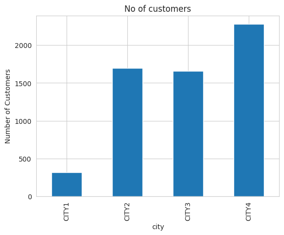

```python
#Bar plot
status_counts = TEST_customer_df.groupby('City')['CustomerID'].count()

# create a bar plot
status_counts.plot(kind='bar')

# add labels and title
plt.title('No of customers')
plt.xlabel('city')
plt.ylabel('Number of Customers')

# show the plot
plt.show()
```

**Observations**

We have the highest customers from CITY4 and lowest from CITY1

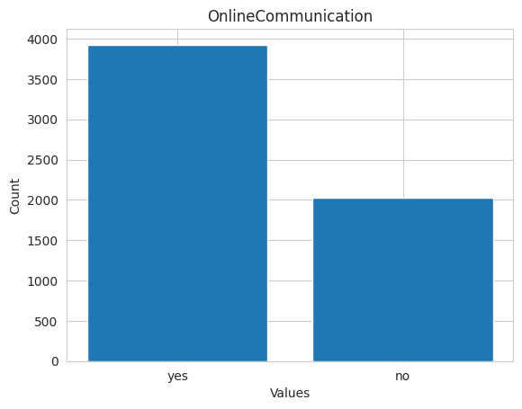

```python
# count the number of occurrences of each value
value_counts = TEST_customer_df['OnlineCommunication'].value_counts()

# create a bar plot
plt.bar(['yes', 'no'], [value_counts[1], value_counts[0]])

# set the chart title and axis labels
plt.title('OnlineCommunication')
plt.xlabel('Values')
plt.ylabel('Count')

# display the chart
plt.show()
```

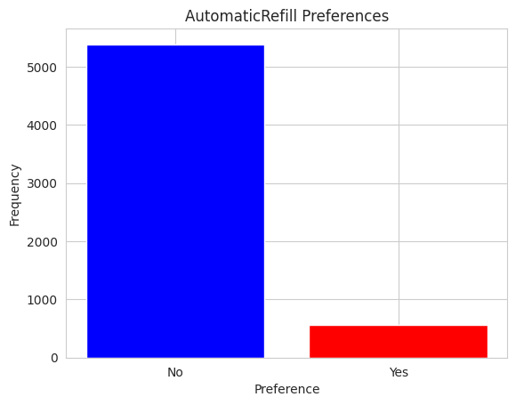

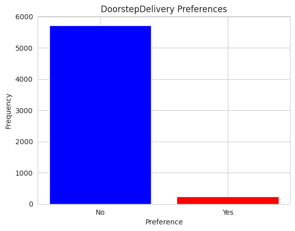

```python
  elem = [ 'AutomaticRefill', 'DoorstepDelivery']

# Iterate over each column
for col in elem:
    # Count the number of customers who preferred and did not prefer
    counts = TEST_customer_df[col].value_counts()

    # Create a bar plot
    plt.bar(['No', 'Yes'], counts.values, color=['blue', 'red'])

    # Set the title and labels
    plt.title(col + ' Preferences')
    plt.xlabel('Preference')
    plt.ylabel('Frequency')

    # Display the plot
    plt.show()
```

# TEST_email_df

```python
TEST_email_df=TEST_email_df.drop(['timestamp','DateOfemail'],axis=1)
TEST_email_df
```

|  | CustomerID | EmailType | MailOpened | MailClicked |
| --- | --- | --- | --- | --- |
| 0 | C17838 | WelcomeEmail | yes | NotApplicable |
| 1 | C12403 | WelcomeEmail | yes | NotApplicable |
| 2 | C19041 | WelcomeEmail | yes | NotApplicable |
| 3 | C24069 | WelcomeEmail | yes | NotApplicable |
| 4 | C26718 | WelcomeEmail | yes | NotApplicable |
| ... | ... | ... | ... | ... |
| 129069 | C30169 | CustomizedEmail | no | no |
| 129070 | C30169 | CustomizedEmail | no | no |
| 129071 | C30169 | CustomizedEmail | yes | yes |
| 129072 | C30169 | CustomizedEmail | yes | no |
| 129073 | C30169 | CustomizedEmail | yes | no |

129074 rows × 4 columns

```python
# Define the function to calculate new column(welcome email opened or not)
def is_welcome_opened(row):
    if row['EmailType'] == 'WelcomeEmail' and row['MailOpened'] == 'yes':
        return 1  #yes =1
    else:
        return 1  #no=1
```

```python
# Calculate the welcome email opened or not column
TEST_email_df1 = pd.DataFrame()
TEST_email_df1['CustomerID'] = TEST_email_df['CustomerID'].unique()
TEST_email_df1['welcome_email_opened'] = TEST_email_df.apply(is_welcome_opened, axis=1)

# Display the email_df1 DataFrame
TEST_email_df1
```

|  | CustomerID | welcome_email_opened |
| --- | --- | --- |
| 0 | C17838 | 1 |
| 1 | C12403 | 1 |
| 2 | C19041 | 1 |
| 3 | C24069 | 1 |
| 4 | C26718 | 1 |
| ... | ... | ... |
| 5950 | C32947 | 1 |
| 5951 | C28951 | 1 |
| 5952 | C38741 | 1 |
| 5953 | C20407 | 1 |
| 5954 | C27220 | 1 |

5955 rows × 2 columns

```python
#creating new TEST_email_df2
TEST_email_df2 = TEST_email_df.groupby('CustomerID').agg(
    no_of_customized_email=('EmailType', lambda x: (x == 'CustomizedEmail').sum()),
    no_of_customized_email_opened=('MailOpened', lambda x: ((TEST_email_df.loc[x.index, 'EmailType'] == 'CustomizedEmail') & (x == 'yes')).sum()),
    no_of_customized_email_clicked=('MailClicked', lambda x: ((TEST_email_df.loc[x.index, 'EmailType'] == 'CustomizedEmail') & (x == 'yes')).sum())
).reset_index()

# Display the new DataFrame
TEST_email_df2
```

|  | CustomerID | no_of_customized_email | no_of_customized_email_opened | no_of_customized_email_clicked |
| --- | --- | --- | --- | --- |
| 0 | C12121 | 24 | 8 | 3 |
| 1 | C12132 | 0 | 0 | 0 |
| 2 | C12134 | 0 | 0 | 0 |
| 3 | C12135 | 29 | 8 | 5 |
| 4 | C12136 | 41 | 3 | 1 |
| ... | ... | ... | ... | ... |
| 5950 | C42153 | 10 | 2 | 1 |
| 5951 | C42155 | 0 | 0 | 0 |
| 5952 | C42157 | 0 | 0 | 0 |
| 5953 | C42167 | 49 | 3 | 1 |
| 5954 | C42190 | 0 | 0 | 0 |

5955 rows × 4 columns

```python
#merging email_df1 and email_df2 based on CustomerID
clean_TEST_email_df= pd.merge(TEST_email_df1, TEST_email_df2, on='CustomerID')
clean_TEST_email_df
```

|  | CustomerID | welcome_email_opened | no_of_customized_email | no_of_customized_email_opened | no_of_customized_email_clicked |
| --- | --- | --- | --- | --- | --- |
| 0 | C17838 | 1 | 0 | 0 | 0 |
| 1 | C12403 | 1 | 46 | 37 | 7 |
| 2 | C19041 | 1 | 60 | 26 | 4 |
| 3 | C24069 | 1 | 45 | 0 | 0 |
| 4 | C26718 | 1 | 13 | 8 | 2 |
| ... | ... | ... | ... | ... | ... |
| 5950 | C32947 | 1 | 0 | 0 | 0 |
| 5951 | C28951 | 1 | 0 | 0 | 0 |
| 5952 | C38741 | 1 | 0 | 0 | 0 |
| 5953 | C20407 | 1 | 0 | 0 | 0 |
| 5954 | C27220 | 1 | 0 | 0 | 0 |

5955 rows × 5 columns

# TEST_transaction_df

```python
TEST_transaction_df
```

|  | CustomerID | DateOfOrder | timestamp | OrderQuantity |
| --- | --- | --- | --- | --- |
| 0 | C17838 | 2011-03-28 | 17:41:08 | 55 |
| 1 | C12403 | 2010-10-12 | 15:58:02 | 174 |
| 2 | C12403 | 2010-11-27 | 20:13:48 | 171 |
| 3 | C12403 | 2011-12-09 | 14:34:44 | 166 |
| 4 | C12403 | 2011-03-04 | 18:20:18 | 179 |
| ... | ... | ... | ... | ... |
| 26763 | C32947 | 2018-01-17 | 21:35:26 | 41 |
| 26764 | C28951 | 2018-01-17 | 17:05:50 | 40 |
| 26765 | C38741 | 2018-01-17 | 18:56:16 | 36 |
| 26766 | C20407 | 2018-01-17 | 10:24:52 | 75 |
| 26767 | C27220 | 2018-01-17 | 12:04:10 | 40 |

26768 rows × 4 columns

```python
TEST_transaction_df1=TEST_transaction_df.loc[:, ["CustomerID", "DateOfOrder"]]
TEST_transaction_df1
```

|  | CustomerID | DateOfOrder |
| --- | --- | --- |
| 0 | C17838 | 2011-03-28 |
| 1 | C12403 | 2010-10-12 |
| 2 | C12403 | 2010-11-27 |
| 3 | C12403 | 2011-12-09 |
| 4 | C12403 | 2011-03-04 |
| ... | ... | ... |
| 26763 | C32947 | 2018-01-17 |
| 26764 | C28951 | 2018-01-17 |
| 26765 | C38741 | 2018-01-17 |
| 26766 | C20407 | 2018-01-17 |
| 26767 | C27220 | 2018-01-17 |

26768 rows × 2 columns

```python
TEST_transaction_df2=TEST_transaction_df.loc[:, ["CustomerID", "OrderQuantity"]]
TEST_transaction_df2
```

|  | CustomerID | OrderQuantity |
| --- | --- | --- |
| 0 | C17838 | 55 |
| 1 | C12403 | 174 |
| 2 | C12403 | 171 |
| 3 | C12403 | 166 |
| 4 | C12403 | 179 |
| ... | ... | ... |
| 26763 | C32947 | 41 |
| 26764 | C28951 | 40 |
| 26765 | C38741 | 36 |
| 26766 | C20407 | 75 |
| 26767 | C27220 | 40 |

26768 rows × 2 columns

```python
TEST_transaction_df3=TEST_transaction_df.loc[:, ["CustomerID", "DateOfOrder"]]
TEST_transaction_df3
```

|  | CustomerID | DateOfOrder |
| --- | --- | --- |
| 0 | C17838 | 2011-03-28 |
| 1 | C12403 | 2010-10-12 |
| 2 | C12403 | 2010-11-27 |
| 3 | C12403 | 2011-12-09 |
| 4 | C12403 | 2011-03-04 |
| ... | ... | ... |
| 26763 | C32947 | 2018-01-17 |
| 26764 | C28951 | 2018-01-17 |
| 26765 | C38741 | 2018-01-17 |
| 26766 | C20407 | 2018-01-17 |
| 26767 | C27220 | 2018-01-17 |

26768 rows × 2 columns

```python
TEST_transaction_df1['DateOfOrder'] = pd.to_datetime(TEST_transaction_df1['DateOfOrder'])
TEST_transaction_df1 =TEST_transaction_df1.sort_values(['CustomerID', 'DateOfOrder'])
TEST_transaction_df1.head()
```

|  | CustomerID | DateOfOrder |
| --- | --- | --- |
| 26576 | C12121 | 2017-12-14 |
| 19363 | C12132 | 2013-10-20 |
| 17770 | C12134 | 2013-09-18 |
| 26401 | C12135 | 2018-01-10 |
| 18455 | C12136 | 2013-10-19 |

```python
#creating ordergap column
TEST_transaction_df1['OrderGap'] = TEST_transaction_df1.groupby('CustomerID')['DateOfOrder'].diff().fillna(pd.Timedelta(seconds=0))
TEST_transaction_df1.head()
```

|  | CustomerID | DateOfOrder | OrderGap |
| --- | --- | --- | --- |
| 26576 | C12121 | 2017-12-14 | 0 days |
| 19363 | C12132 | 2013-10-20 | 0 days |
| 17770 | C12134 | 2013-09-18 | 0 days |
| 26401 | C12135 | 2018-01-10 | 0 days |
| 18455 | C12136 | 2013-10-19 | 0 days |

```python
#removinng days string from OrderGap
TEST_transaction_df1['OrderGap'] = (TEST_transaction_df1['OrderGap'].dt.total_seconds() / 86400).astype(int)
TEST_transaction_df1.head()
```

|  | CustomerID | DateOfOrder | OrderGap |
| --- | --- | --- | --- |
| 26576 | C12121 | 2017-12-14 | 0 |
| 19363 | C12132 | 2013-10-20 | 0 |
| 17770 | C12134 | 2013-09-18 | 0 |
| 26401 | C12135 | 2018-01-10 | 0 |
| 18455 | C12136 | 2013-10-19 | 0 |

```python
TEST_transaction_df1 = TEST_transaction_df1.groupby('CustomerID')['OrderGap'].mean().reset_index()
TEST_transaction_df1.columns = ['CustomerID', 'Average_Ordergap']
TEST_transaction_df1.head()
```

|  | CustomerID | Average_Ordergap |
| --- | --- | --- |
| 0 | C12121 | 0.0 |
| 1 | C12132 | 0.0 |
| 2 | C12134 | 0.0 |
| 3 | C12135 | 0.0 |
| 4 | C12136 | 0.0 |

```python
# group by ID and aggregate the order quantity by sum
TEST_transaction_df2 = TEST_transaction_df2.groupby('CustomerID')['OrderQuantity'].agg(['sum', 'count']).reset_index()

# rename the columns
TEST_transaction_df2 = TEST_transaction_df2.rename(columns={'sum': 'TotalOrderQuantity', 'count': 'OrderFrequency'})

# print the new DataFrame
TEST_transaction_df2
```

|  | CustomerID | TotalOrderQuantity | OrderFrequency |
| --- | --- | --- | --- |
| 0 | C12121 | 52 | 1 |
| 1 | C12132 | 40 | 1 |
| 2 | C12134 | 40 | 1 |
| 3 | C12135 | 41 | 1 |
| 4 | C12136 | 79 | 1 |
| ... | ... | ... | ... |
| 5950 | C42153 | 379 | 5 |
| 5951 | C42155 | 41 | 1 |
| 5952 | C42157 | 41 | 1 |
| 5953 | C42167 | 502 | 6 |
| 5954 | C42190 | 40 | 1 |

5955 rows × 3 columns

```python
# Convert dateoforder to datetime format
TEST_transaction_df3['DateOfOrder'] = pd.to_datetime(TEST_transaction_df3['DateOfOrder'])

# Group the transactions by 'id' and extract the first and last order dates for each group
first_order = TEST_transaction_df3.groupby('CustomerID')['DateOfOrder'].min().reset_index()
last_order = TEST_transaction_df3.groupby('CustomerID')['DateOfOrder'].max().reset_index()

# Merge the first_order and last_order DataFrames
TEST_transaction_df3 = pd.merge(first_order, last_order, on='CustomerID')

# Rename the columns
TEST_transaction_df3.columns = ['CustomerID', 'firstOrder', 'lastOrder']

# Print the result
TEST_transaction_df3
```

|  | CustomerID | firstOrder | lastOrder |
| --- | --- | --- | --- |
| 0 | C12121 | 2017-12-14 | 2017-12-14 |
| 1 | C12132 | 2013-10-20 | 2013-10-20 |
| 2 | C12134 | 2013-09-18 | 2013-09-18 |
| 3 | C12135 | 2018-01-10 | 2018-01-10 |
| 4 | C12136 | 2013-10-19 | 2013-10-19 |
| ... | ... | ... | ... |
| 5950 | C42153 | 2012-10-18 | 2012-11-16 |
| 5951 | C42155 | 2013-09-14 | 2013-09-14 |
| 5952 | C42157 | 2013-09-30 | 2013-09-30 |
| 5953 | C42167 | 2016-10-28 | 2017-11-06 |
| 5954 | C42190 | 2013-09-06 | 2013-09-06 |

5955 rows × 3 columns

```python
merged_transaction_df1= pd.merge(TEST_transaction_df2, TEST_transaction_df1, on='CustomerID')
clean_TEST_transaction_df= pd.merge(merged_transaction_df1, TEST_transaction_df3, on='CustomerID')
clean_TEST_transaction_df
```

|  | CustomerID | TotalOrderQuantity | OrderFrequency | Average_Ordergap | firstOrder | lastOrder |
| --- | --- | --- | --- | --- | --- | --- |
| 0 | C12121 | 52 | 1 | 0.000000 | 2017-12-14 | 2017-12-14 |
| 1 | C12132 | 40 | 1 | 0.000000 | 2013-10-20 | 2013-10-20 |
| 2 | C12134 | 40 | 1 | 0.000000 | 2013-09-18 | 2013-09-18 |
| 3 | C12135 | 41 | 1 | 0.000000 | 2018-01-10 | 2018-01-10 |
| 4 | C12136 | 79 | 1 | 0.000000 | 2013-10-19 | 2013-10-19 |
| ... | ... | ... | ... | ... | ... | ... |
| 5950 | C42153 | 379 | 5 | 5.800000 | 2012-10-18 | 2012-11-16 |
| 5951 | C42155 | 41 | 1 | 0.000000 | 2013-09-14 | 2013-09-14 |
| 5952 | C42157 | 41 | 1 | 0.000000 | 2013-09-30 | 2013-09-30 |
| 5953 | C42167 | 502 | 6 | 62.333333 | 2016-10-28 | 2017-11-06 |
| 5954 | C42190 | 40 | 1 | 0.000000 | 2013-09-06 | 2013-09-06 |

5955 rows × 6 columns

## Merging 4 dataframes

```python
test_merged_df1 = pd.merge(TEST_customer_df,clean_TEST_email_df, on='CustomerID')
test_merged_df2 = pd.merge(test_merged_df1, clean_TEST_transaction_df, on='CustomerID')
test_final_merged_df = pd.merge(TEST_df1,test_merged_df2 , on='CustomerID')
test_final_merged_df
```

|  | CustomerID | City | DateOfRegistration | OnlineCommunication | AutomaticRefill | DoorstepDelivery | PreferredDeliveryDay | welcome_email_opened | no_of_customized_email | no_of_customized_email_opened | no_of_customized_email_clicked | TotalOrderQuantity | OrderFrequency | Average_Ordergap | firstOrder | lastOrder |
| --- | --- | --- | --- | --- | --- | --- | --- | --- | --- | --- | --- | --- | --- | --- | --- | --- |
| 0 | C12121 | CITY1 | 2017-12-04 | 1 | 0 | 0 | Friday | 1 | 24 | 8 | 3 | 52 | 1 | 0.000000 | 2017-12-14 | 2017-12-14 |
| 1 | C12132 | CITY3 | 2013-10-20 | 1 | 0 | 0 | Tuesday | 1 | 0 | 0 | 0 | 40 | 1 | 0.000000 | 2013-10-20 | 2013-10-20 |
| 2 | C12134 | CITY3 | 2013-09-18 | 1 | 0 | 0 | Monday | 1 | 0 | 0 | 0 | 40 | 1 | 0.000000 | 2013-09-18 | 2013-09-18 |
| 3 | C12135 | CITY3 | 2017-11-01 | 1 | 0 | 1 | Wednesday | 1 | 29 | 8 | 5 | 41 | 1 | 0.000000 | 2018-01-10 | 2018-01-10 |
| 4 | C12136 | CITY2 | 2013-09-28 | 1 | 0 | 0 | Thursday | 1 | 41 | 3 | 1 | 79 | 1 | 0.000000 | 2013-10-19 | 2013-10-19 |
| ... | ... | ... | ... | ... | ... | ... | ... | ... | ... | ... | ... | ... | ... | ... | ... | ... |
| 5950 | C42153 | CITY1 | 2012-08-28 | 1 | 0 | 0 | Sunday | 1 | 10 | 2 | 1 | 379 | 5 | 5.800000 | 2012-10-18 | 2012-11-16 |
| 5951 | C42155 | CITY4 | 2013-09-14 | 1 | 0 | 0 | Thursday | 1 | 0 | 0 | 0 | 41 | 1 | 0.000000 | 2013-09-14 | 2013-09-14 |
| 5952 | C42157 | CITY4 | 2013-09-30 | 1 | 0 | 0 | Tuesday | 1 | 0 | 0 | 0 | 41 | 1 | 0.000000 | 2013-09-30 | 2013-09-30 |
| 5953 | C42167 | CITY2 | 2016-10-28 | 0 | 0 | 0 | Monday | 1 | 49 | 3 | 1 | 502 | 6 | 62.333333 | 2016-10-28 | 2017-11-06 |
| 5954 | C42190 | CITY3 | 2013-09-06 | 1 | 0 | 0 | Monday | 1 | 0 | 0 | 0 | 40 | 1 | 0.000000 | 2013-09-06 | 2013-09-06 |

5955 rows × 16 columns

## Feature Engineering

```python
# Calculate the differences in days and add them as new columns
test_final_merged_df['no_of_DayswithBusiness'] = (test_final_merged_df['lastOrder'] - test_final_merged_df['DateOfRegistration']).dt.days.abs()
test_final_merged_df['no_of_MakingBusinessDays'] = (test_final_merged_df['lastOrder'] - test_final_merged_df['firstOrder']).dt.days.abs()
test_final_merged_df
```

|  | CustomerID | City | DateOfRegistration | OnlineCommunication | AutomaticRefill | DoorstepDelivery | PreferredDeliveryDay | welcome_email_opened | no_of_customized_email | no_of_customized_email_opened | no_of_customized_email_clicked | TotalOrderQuantity | OrderFrequency | Average_Ordergap | firstOrder | lastOrder | no_of_DayswithBusiness | no_of_MakingBusinessDays |
| --- | --- | --- | --- | --- | --- | --- | --- | --- | --- | --- | --- | --- | --- | --- | --- | --- | --- | --- |
| 0 | C12121 | CITY1 | 2017-12-04 | 1 | 0 | 0 | Friday | 1 | 24 | 8 | 3 | 52 | 1 | 0.000000 | 2017-12-14 | 2017-12-14 | 10 | 0 |
| 1 | C12132 | CITY3 | 2013-10-20 | 1 | 0 | 0 | Tuesday | 1 | 0 | 0 | 0 | 40 | 1 | 0.000000 | 2013-10-20 | 2013-10-20 | 0 | 0 |
| 2 | C12134 | CITY3 | 2013-09-18 | 1 | 0 | 0 | Monday | 1 | 0 | 0 | 0 | 40 | 1 | 0.000000 | 2013-09-18 | 2013-09-18 | 0 | 0 |
| 3 | C12135 | CITY3 | 2017-11-01 | 1 | 0 | 1 | Wednesday | 1 | 29 | 8 | 5 | 41 | 1 | 0.000000 | 2018-01-10 | 2018-01-10 | 70 | 0 |
| 4 | C12136 | CITY2 | 2013-09-28 | 1 | 0 | 0 | Thursday | 1 | 41 | 3 | 1 | 79 | 1 | 0.000000 | 2013-10-19 | 2013-10-19 | 21 | 0 |
| ... | ... | ... | ... | ... | ... | ... | ... | ... | ... | ... | ... | ... | ... | ... | ... | ... | ... | ... |
| 5950 | C42153 | CITY1 | 2012-08-28 | 1 | 0 | 0 | Sunday | 1 | 10 | 2 | 1 | 379 | 5 | 5.800000 | 2012-10-18 | 2012-11-16 | 80 | 29 |
| 5951 | C42155 | CITY4 | 2013-09-14 | 1 | 0 | 0 | Thursday | 1 | 0 | 0 | 0 | 41 | 1 | 0.000000 | 2013-09-14 | 2013-09-14 | 0 | 0 |
| 5952 | C42157 | CITY4 | 2013-09-30 | 1 | 0 | 0 | Tuesday | 1 | 0 | 0 | 0 | 41 | 1 | 0.000000 | 2013-09-30 | 2013-09-30 | 0 | 0 |
| 5953 | C42167 | CITY2 | 2016-10-28 | 0 | 0 | 0 | Monday | 1 | 49 | 3 | 1 | 502 | 6 | 62.333333 | 2016-10-28 | 2017-11-06 | 374 | 374 |
| 5954 | C42190 | CITY3 | 2013-09-06 | 1 | 0 | 0 | Monday | 1 | 0 | 0 | 0 | 40 | 1 | 0.000000 | 2013-09-06 | 2013-09-06 | 0 | 0 |

5955 rows × 18 columns

```python
TEST_df=test_final_merged_df.drop(['DateOfRegistration','firstOrder','lastOrder'],axis=1)
TEST_df
```

|  | CustomerID | City | OnlineCommunication | AutomaticRefill | DoorstepDelivery | PreferredDeliveryDay | welcome_email_opened | no_of_customized_email | no_of_customized_email_opened | no_of_customized_email_clicked | TotalOrderQuantity | OrderFrequency | Average_Ordergap | no_of_DayswithBusiness | no_of_MakingBusinessDays |
| --- | --- | --- | --- | --- | --- | --- | --- | --- | --- | --- | --- | --- | --- | --- | --- |
| 0 | C12121 | CITY1 | 1 | 0 | 0 | Friday | 1 | 24 | 8 | 3 | 52 | 1 | 0.000000 | 10 | 0 |
| 1 | C12132 | CITY3 | 1 | 0 | 0 | Tuesday | 1 | 0 | 0 | 0 | 40 | 1 | 0.000000 | 0 | 0 |
| 2 | C12134 | CITY3 | 1 | 0 | 0 | Monday | 1 | 0 | 0 | 0 | 40 | 1 | 0.000000 | 0 | 0 |
| 3 | C12135 | CITY3 | 1 | 0 | 1 | Wednesday | 1 | 29 | 8 | 5 | 41 | 1 | 0.000000 | 70 | 0 |
| 4 | C12136 | CITY2 | 1 | 0 | 0 | Thursday | 1 | 41 | 3 | 1 | 79 | 1 | 0.000000 | 21 | 0 |
| ... | ... | ... | ... | ... | ... | ... | ... | ... | ... | ... | ... | ... | ... | ... | ... |
| 5950 | C42153 | CITY1 | 1 | 0 | 0 | Sunday | 1 | 10 | 2 | 1 | 379 | 5 | 5.800000 | 80 | 29 |
| 5951 | C42155 | CITY4 | 1 | 0 | 0 | Thursday | 1 | 0 | 0 | 0 | 41 | 1 | 0.000000 | 0 | 0 |
| 5952 | C42157 | CITY4 | 1 | 0 | 0 | Tuesday | 1 | 0 | 0 | 0 | 41 | 1 | 0.000000 | 0 | 0 |
| 5953 | C42167 | CITY2 | 0 | 0 | 0 | Monday | 1 | 49 | 3 | 1 | 502 | 6 | 62.333333 | 374 | 374 |
| 5954 | C42190 | CITY3 | 1 | 0 | 0 | Monday | 1 | 0 | 0 | 0 | 40 | 1 | 0.000000 | 0 | 0 |

5955 rows × 15 columns

# encoding

```python
cat_cols=["City", "PreferredDeliveryDay"]

# Convert categorical columns into dummy variables
df_dummies = pd.get_dummies(TEST_df[cat_cols],columns=cat_cols, drop_first=True)

# Concatenate the dummy variables with the original dataframe
TEST_df = pd.concat([TEST_df, df_dummies], axis=1)

# Drop the original categorical columns
TEST_df.drop(columns=cat_cols, inplace=True)

# Print the updated dataframe
TEST_df.head()
```

|  | CustomerID | OnlineCommunication | AutomaticRefill | DoorstepDelivery | welcome_email_opened | no_of_customized_email | no_of_customized_email_opened | no_of_customized_email_clicked | TotalOrderQuantity | OrderFrequency | Average_Ordergap | no_of_DayswithBusiness | no_of_MakingBusinessDays | City_CITY2 | City_CITY3 | City_CITY4 | PreferredDeliveryDay_Monday | PreferredDeliveryDay_Saturday | PreferredDeliveryDay_Sunday | PreferredDeliveryDay_Thursday | PreferredDeliveryDay_Tuesday | PreferredDeliveryDay_Wednesday |
| --- | --- | --- | --- | --- | --- | --- | --- | --- | --- | --- | --- | --- | --- | --- | --- | --- | --- | --- | --- | --- | --- | --- |
| 0 | C12121 | 1 | 0 | 0 | 1 | 24 | 8 | 3 | 52 | 1 | 0.0 | 10 | 0 | 0 | 0 | 0 | 0 | 0 | 0 | 0 | 0 | 0 |
| 1 | C12132 | 1 | 0 | 0 | 1 | 0 | 0 | 0 | 40 | 1 | 0.0 | 0 | 0 | 0 | 1 | 0 | 0 | 0 | 0 | 0 | 1 | 0 |
| 2 | C12134 | 1 | 0 | 0 | 1 | 0 | 0 | 0 | 40 | 1 | 0.0 | 0 | 0 | 0 | 1 | 0 | 1 | 0 | 0 | 0 | 0 | 0 |
| 3 | C12135 | 1 | 0 | 1 | 1 | 29 | 8 | 5 | 41 | 1 | 0.0 | 70 | 0 | 0 | 1 | 0 | 0 | 0 | 0 | 0 | 0 | 1 |
| 4 | C12136 | 1 | 0 | 0 | 1 | 41 | 3 | 1 | 79 | 1 | 0.0 | 21 | 0 | 1 | 0 | 0 | 0 | 0 | 0 | 1 | 0 | 0 |

```python
TEST_df.shape
```

```
(5955, 22)
```

## checking skewness

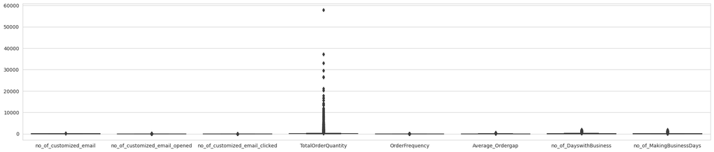

```python
# select columns to plot
columns_to_plot = ['no_of_customized_email', 'no_of_customized_email_opened', 'no_of_customized_email_clicked','TotalOrderQuantity','OrderFrequency','Average_Ordergap','no_of_DayswithBusiness','no_of_MakingBusinessDays']

# plot box plots for selected columns
plt.figure(figsize=(25, 5))
sns.boxplot(data=TEST_df[columns_to_plot])
```

```python
for column in ['TotalOrderQuantity', 'no_of_DayswithBusiness', 'no_of_MakingBusinessDays']:
    skewness = TEST_df[column].skew()
    print(f"The skewness of {column} is {skewness:.2f}")
```

```
The skewness of TotalOrderQuantity is 15.34
The skewness of no_of_DayswithBusiness is 2.95
The skewness of no_of_MakingBusinessDays is 3.38
```

```python
TEST_df['TotalOrderQuantity'] = np.sqrt(TEST_df['TotalOrderQuantity'])
TEST_df['no_of_DayswithBusiness'] = np.sqrt(TEST_df['no_of_DayswithBusiness'])
TEST_df['no_of_MakingBusinessDays'] = np.sqrt(TEST_df['no_of_MakingBusinessDays'])
```

```python
TEST_df
```

|  | CustomerID | OnlineCommunication | AutomaticRefill | DoorstepDelivery | welcome_email_opened | no_of_customized_email | no_of_customized_email_opened | no_of_customized_email_clicked | TotalOrderQuantity | OrderFrequency | Average_Ordergap | no_of_DayswithBusiness | no_of_MakingBusinessDays | City_CITY2 | City_CITY3 | City_CITY4 | PreferredDeliveryDay_Monday | PreferredDeliveryDay_Saturday | PreferredDeliveryDay_Sunday | PreferredDeliveryDay_Thursday | PreferredDeliveryDay_Tuesday | PreferredDeliveryDay_Wednesday |
| --- | --- | --- | --- | --- | --- | --- | --- | --- | --- | --- | --- | --- | --- | --- | --- | --- | --- | --- | --- | --- | --- | --- |
| 0 | C12121 | 1 | 0 | 0 | 1 | 24 | 8 | 3 | 7.211103 | 1 | 0.000000 | 3.162278 | 0.000000 | 0 | 0 | 0 | 0 | 0 | 0 | 0 | 0 | 0 |
| 1 | C12132 | 1 | 0 | 0 | 1 | 0 | 0 | 0 | 6.324555 | 1 | 0.000000 | 0.000000 | 0.000000 | 0 | 1 | 0 | 0 | 0 | 0 | 0 | 1 | 0 |
| 2 | C12134 | 1 | 0 | 0 | 1 | 0 | 0 | 0 | 6.324555 | 1 | 0.000000 | 0.000000 | 0.000000 | 0 | 1 | 0 | 1 | 0 | 0 | 0 | 0 | 0 |
| 3 | C12135 | 1 | 0 | 1 | 1 | 29 | 8 | 5 | 6.403124 | 1 | 0.000000 | 8.366600 | 0.000000 | 0 | 1 | 0 | 0 | 0 | 0 | 0 | 0 | 1 |
| 4 | C12136 | 1 | 0 | 0 | 1 | 41 | 3 | 1 | 8.888194 | 1 | 0.000000 | 4.582576 | 0.000000 | 1 | 0 | 0 | 0 | 0 | 0 | 1 | 0 | 0 |
| ... | ... | ... | ... | ... | ... | ... | ... | ... | ... | ... | ... | ... | ... | ... | ... | ... | ... | ... | ... | ... | ... | ... |
| 5950 | C42153 | 1 | 0 | 0 | 1 | 10 | 2 | 1 | 19.467922 | 5 | 5.800000 | 8.944272 | 5.385165 | 0 | 0 | 0 | 0 | 0 | 1 | 0 | 0 | 0 |
| 5951 | C42155 | 1 | 0 | 0 | 1 | 0 | 0 | 0 | 6.403124 | 1 | 0.000000 | 0.000000 | 0.000000 | 0 | 0 | 1 | 0 | 0 | 0 | 1 | 0 | 0 |
| 5952 | C42157 | 1 | 0 | 0 | 1 | 0 | 0 | 0 | 6.403124 | 1 | 0.000000 | 0.000000 | 0.000000 | 0 | 0 | 1 | 0 | 0 | 0 | 0 | 1 | 0 |
| 5953 | C42167 | 0 | 0 | 0 | 1 | 49 | 3 | 1 | 22.405357 | 6 | 62.333333 | 19.339080 | 19.339080 | 1 | 0 | 0 | 1 | 0 | 0 | 0 | 0 | 0 |
| 5954 | C42190 | 1 | 0 | 0 | 1 | 0 | 0 | 0 | 6.324555 | 1 | 0.000000 | 0.000000 | 0.000000 | 0 | 1 | 0 | 1 | 0 | 0 | 0 | 0 | 0 |

5955 rows × 22 columns

Storing TEST_df['CustomerID'] values in ids for creating submission file

```python
ids=TEST_df['CustomerID']
ids.shape
```

```
(5955,)
```

```python
TEST_df=TEST_df.drop("CustomerID",axis=1)
TEST_df
```

|  | OnlineCommunication | AutomaticRefill | DoorstepDelivery | welcome_email_opened | no_of_customized_email | no_of_customized_email_opened | no_of_customized_email_clicked | TotalOrderQuantity | OrderFrequency | Average_Ordergap | no_of_DayswithBusiness | no_of_MakingBusinessDays | City_CITY2 | City_CITY3 | City_CITY4 | PreferredDeliveryDay_Monday | PreferredDeliveryDay_Saturday | PreferredDeliveryDay_Sunday | PreferredDeliveryDay_Thursday | PreferredDeliveryDay_Tuesday | PreferredDeliveryDay_Wednesday |
| --- | --- | --- | --- | --- | --- | --- | --- | --- | --- | --- | --- | --- | --- | --- | --- | --- | --- | --- | --- | --- | --- |
| 0 | 1 | 0 | 0 | 1 | 24 | 8 | 3 | 7.211103 | 1 | 0.000000 | 3.162278 | 0.000000 | 0 | 0 | 0 | 0 | 0 | 0 | 0 | 0 | 0 |
| 1 | 1 | 0 | 0 | 1 | 0 | 0 | 0 | 6.324555 | 1 | 0.000000 | 0.000000 | 0.000000 | 0 | 1 | 0 | 0 | 0 | 0 | 0 | 1 | 0 |
| 2 | 1 | 0 | 0 | 1 | 0 | 0 | 0 | 6.324555 | 1 | 0.000000 | 0.000000 | 0.000000 | 0 | 1 | 0 | 1 | 0 | 0 | 0 | 0 | 0 |
| 3 | 1 | 0 | 1 | 1 | 29 | 8 | 5 | 6.403124 | 1 | 0.000000 | 8.366600 | 0.000000 | 0 | 1 | 0 | 0 | 0 | 0 | 0 | 0 | 1 |
| 4 | 1 | 0 | 0 | 1 | 41 | 3 | 1 | 8.888194 | 1 | 0.000000 | 4.582576 | 0.000000 | 1 | 0 | 0 | 0 | 0 | 0 | 1 | 0 | 0 |
| ... | ... | ... | ... | ... | ... | ... | ... | ... | ... | ... | ... | ... | ... | ... | ... | ... | ... | ... | ... | ... | ... |
| 5950 | 1 | 0 | 0 | 1 | 10 | 2 | 1 | 19.467922 | 5 | 5.800000 | 8.944272 | 5.385165 | 0 | 0 | 0 | 0 | 0 | 1 | 0 | 0 | 0 |
| 5951 | 1 | 0 | 0 | 1 | 0 | 0 | 0 | 6.403124 | 1 | 0.000000 | 0.000000 | 0.000000 | 0 | 0 | 1 | 0 | 0 | 0 | 1 | 0 | 0 |
| 5952 | 1 | 0 | 0 | 1 | 0 | 0 | 0 | 6.403124 | 1 | 0.000000 | 0.000000 | 0.000000 | 0 | 0 | 1 | 0 | 0 | 0 | 0 | 1 | 0 |
| 5953 | 0 | 0 | 0 | 1 | 49 | 3 | 1 | 22.405357 | 6 | 62.333333 | 19.339080 | 19.339080 | 1 | 0 | 0 | 1 | 0 | 0 | 0 | 0 | 0 |
| 5954 | 1 | 0 | 0 | 1 | 0 | 0 | 0 | 6.324555 | 1 | 0.000000 | 0.000000 | 0.000000 | 0 | 1 | 0 | 1 | 0 | 0 | 0 | 0 | 0 |

5955 rows × 21 columns

# Predictions

```python
test_perd_clf=clf_grid_dt2.predict(TEST_df)
sub=pd.DataFrame({"CustomerID":ids,'RetentionPotential':test_perd_clf})
sub.to_csv("submission.csv",index=False)
```

```python
sub=pd.read_csv("submission.csv")
sub.head()
```

|  | CustomerID | RetentionPotential |
| --- | --- | --- |
| 0 | C12121 | 1 |
| 1 | C12132 | 0 |
| 2 | C12134 | 0 |
| 3 | C12135 | 1 |
| 4 | C12136 | 1 |

# creating a pickle file

```python
import pickle
pickle_out=open('classifier.pkl','wb')
pickle.dump(clf_grid_dt2,pickle_out)
pickle_out.close()
```